# Renewvia - Survey Impact Analysis

### Business Operation Hours

**Data Source**: C&I Post-Survey

**Value (Encoding if applied)**: “Yes, they have increased” = 1, “Yes, they have decreased” = -1, “No, it is pretty much the same” = 0

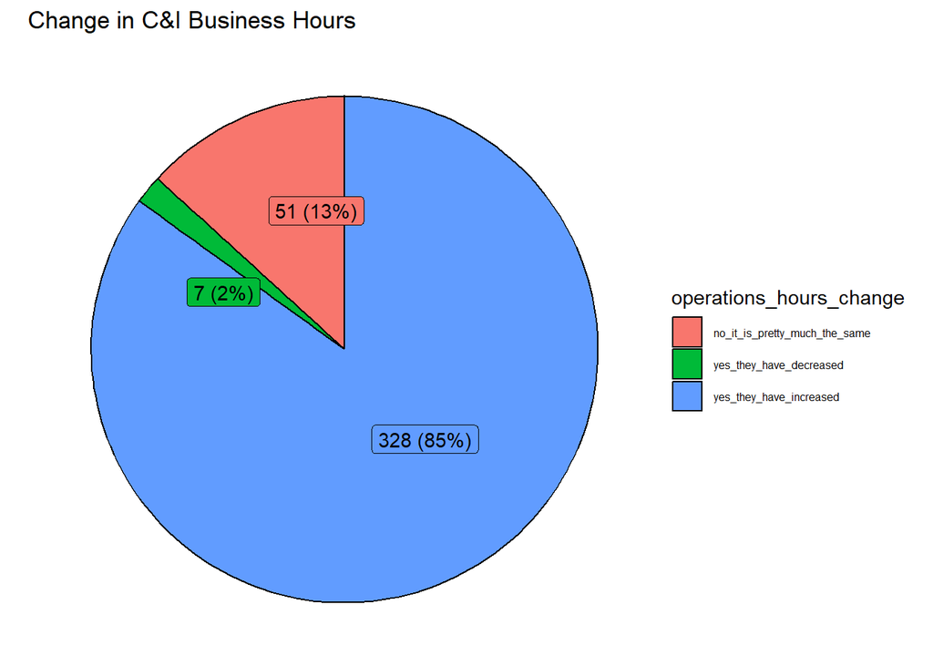

```r
plot_func(df=ci_clean, var_name="operations_hours_change",
          var_type="non_cont", plot_title="Change in C&I Business Hours",
          plot_type="pie", char_remove=NULL)
```

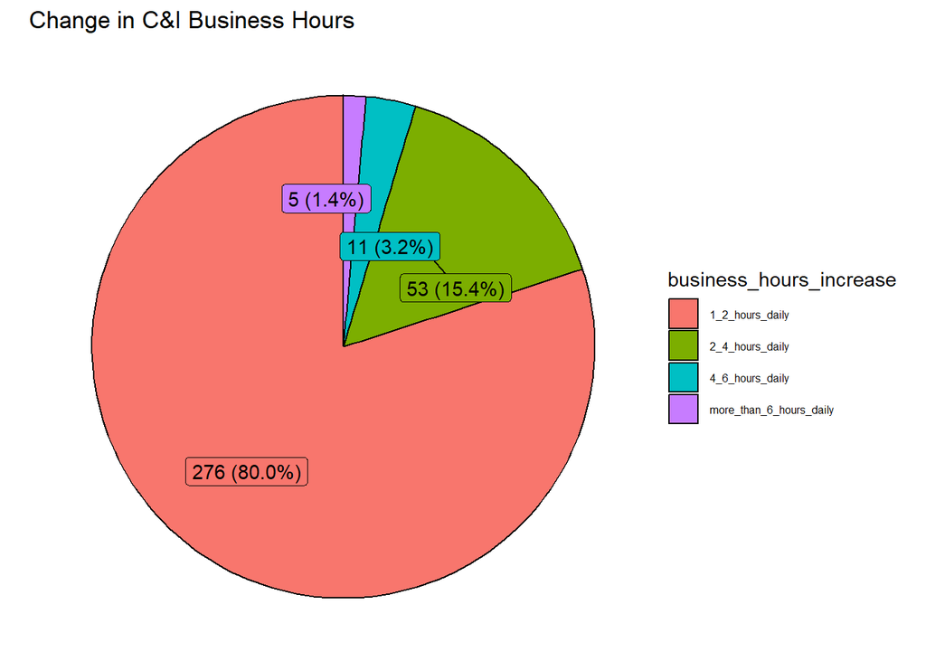

```r
plot_func(df=ci_clean, var_name="business_hours_increase",
          var_type="non_cont", plot_title="Change in C&I Business Hours",
          plot_type="pie", char_remove=NULL)
```

```
## [1] "pv_size_kwh"
##                 Estimate   Std. Error   t value    Pr(>|t|)
## Intercept   0.6068833374 0.1152563093 5.2655108 0.000119426
## pv_size_kwh 0.0007544249 0.0008308199 0.9080487 0.379218275
##                              2.5 %      97.5 %
## (Intercept)            0.359683139 0.854083535
## community_data[, ind] -0.001027507 0.002536356
## [1] "customer_count"
##                    Estimate   Std. Error  t value     Pr(>|t|)
## Intercept      0.6104935729 0.1234359191 4.945834 0.0002151089
## customer_count 0.0001098545 0.0001703828 0.644751 0.5295125882
##                               2.5 %       97.5 %
## (Intercept)            0.3457498569 0.8752372890
## community_data[, ind] -0.0002555803 0.0004752893
## [1] "capex_usd"
##                  Estimate      Std. Error   t value   Pr(>|t|)
## Intercept 0.5389323576394 0.1860510352737 2.8966910 0.01171842
## capex_usd 0.0000004045584 0.0000005507564 0.7345504 0.47473787
##                                  2.5 %         97.5 %
## (Intercept)            0.1398925739110 0.937972141368
## community_data[, ind] -0.0000007766967 0.000001585813
## [1] "consumption"
##                    Estimate     Std. Error   t value     Pr(>|t|)
## Intercept   0.6283261963832 0.128426079708 4.8925125 0.0002375956
## consumption 0.0000004444128 0.000001358877 0.3270443 0.7484729517
##                                 2.5 %         97.5 %
## (Intercept)            0.352879650244 0.903772742522
## community_data[, ind] -0.000002470088 0.000003358913
```

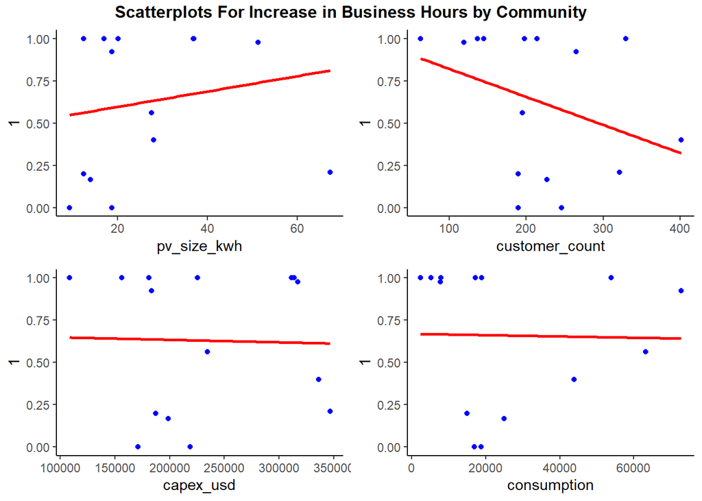

```r
## Since connection to Renewvia mini-grid, have your hours of operation changed at all?
# Check for increase
community_reg(df=ci_enc,
              col_name="operations_hours_change", dep="1", var_type="categorical",
              title="Scatterplots For Increase in Business Hours by Community")
```

### Schools - Academic Performance

**Data Source**: C&I Post-Survey

**Value (Encoding if applied)**: “Yes, they have increased” = 1, “Yes, they have decreased” = -1, “No, it is pretty much the same” = 0

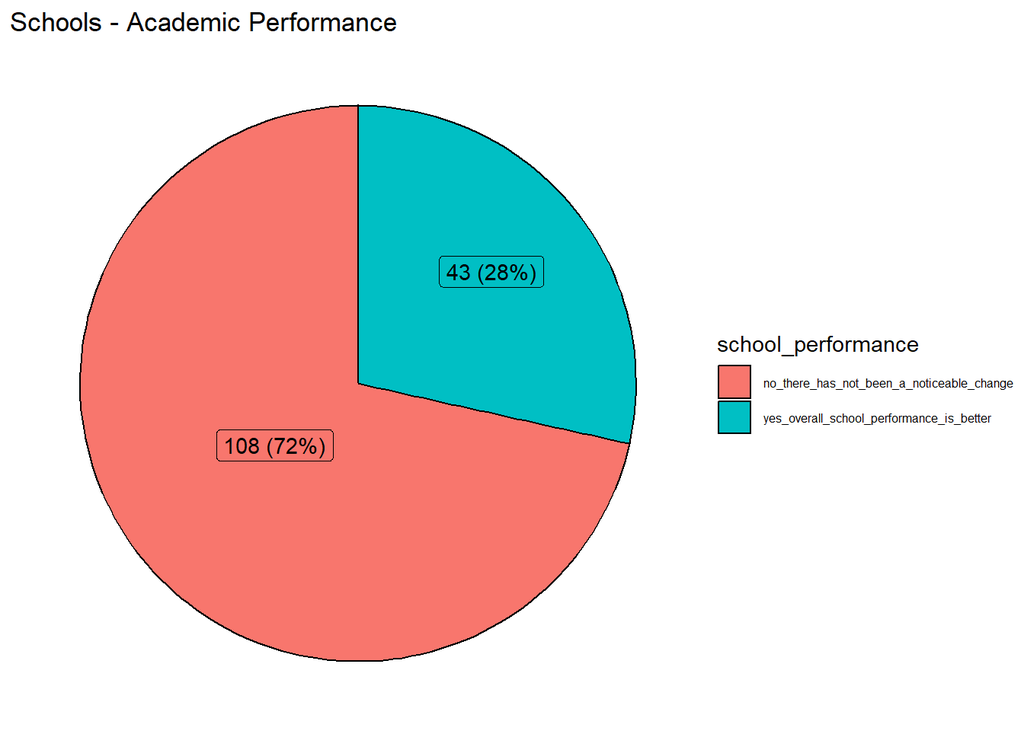

```r
plot_func(df=ci_clean, var_name="school_performance",
          var_type="non_cont", plot_title="Schools - Academic Performance",
          plot_type="pie", char_remove=NULL)
```

```r
## Have you seen a change in overall school performance?
community_reg(df=ci_enc,
              col_name="school_performance", dep="1", var_type="categorical",
              title="Schools - Increase in Academic Performace by Community")
```

```
## [1] "pv_size_kwh"
##                 Estimate   Std. Error   t value     Pr(>|t|)
## Intercept    0.781528595 0.1313578532  5.949615 0.0000671763
## pv_size_kwh -0.001188402 0.0008864607 -1.340614 0.2048735902
##                              2.5 %       97.5 %
## (Intercept)            0.495324419 1.0677327704
## community_data[, ind] -0.003119834 0.0007430299
## [1] "customer_count"
##                    Estimate   Std. Error   t value      Pr(>|t|)
## Intercept       0.813006697 0.1340791828  6.063631 0.00005640024
## customer_count -0.000275594 0.0001741255 -1.582731 0.13946778705
##                               2.5 %      97.5 %
## (Intercept)            0.5208732535 1.105140141
## community_data[, ind] -0.0006549809 0.000103793
## [1] "capex_usd"
##                   Estimate      Std. Error   t value     Pr(>|t|)
## Intercept  0.9257084834301 0.2065096700812  4.482640 0.0007489654
## capex_usd -0.0000007675347 0.0000005853036 -1.311345 0.2142786431
##                                 2.5 %          97.5 %
## (Intercept)            0.475762564807 1.3756544020535
## community_data[, ind] -0.000002042802 0.0000005077323
## [1] "consumption"
##                    Estimate     Std. Error   t value      Pr(>|t|)
## Intercept    0.818797042038 0.142621090885  5.741066 0.00009292817
## consumption -0.000001996414 0.000001414138 -1.411754 0.18342358068
##                                 2.5 %         97.5 %
## (Intercept)            0.508052379438 1.129541704639
## community_data[, ind] -0.000005077556 0.000001084727
```

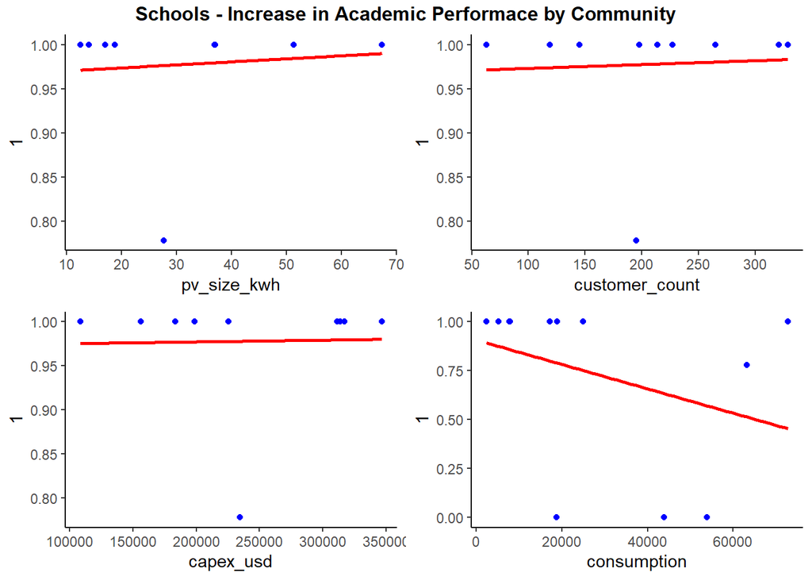

### Household - Academic Performance

**Data Source**: Household Post-Survey

**Value (Encoding if applied)**: “Yes, they have increased” = 1, “Yes, they have decreased” = -1, “No, it is pretty much the same” = 0

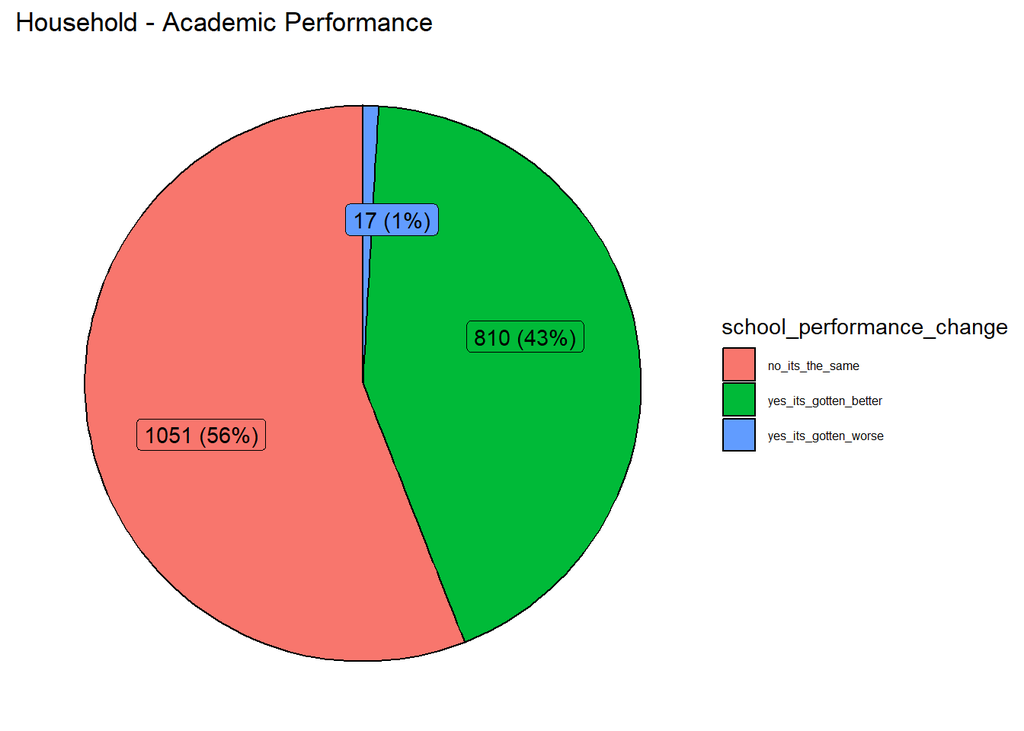

```r
plot_func(df=post_clean, var_name="school_performance_change",
          var_type="non_cont", plot_title="Household - Academic Performance",
          plot_type="pie", char_remove=NULL)
```

```r
community_reg(df=post_enc,
              col_name="school_performance_change",
              dep="1", var_type="categorical",
              title="Households - Increase in Academic Performace by Community")
```

```
## [1] "pv_size_kwh"
##                  Estimate  Std. Error   t value         Pr(>|t|)
## Intercept    0.5503712648 0.062199800  8.848441 0.00000005667122
## pv_size_kwh -0.0008360868 0.000499702 -1.673171 0.11158343271976
##                              2.5 %       97.5 %
## (Intercept)            0.419694333 0.6810481962
## community_data[, ind] -0.001885922 0.0002137482
## [1] "customer_count"
##                     Estimate    Std. Error   t value         Pr(>|t|)
## Intercept       0.5835820056 0.06236712288  9.357206 0.00000002457905
## customer_count -0.0002226045 0.00009474891 -2.349415 0.03041675155657
##                               2.5 %         97.5 %
## (Intercept)            0.4525535425  0.71461046862
## community_data[, ind] -0.0004216646 -0.00002354443
## [1] "capex_usd"
##                   Estimate      Std. Error   t value       Pr(>|t|)
## Intercept  0.6462355694063 0.0992803940974  6.509196 0.000004040362
## capex_usd -0.0000005434442 0.0000003188753 -1.704253 0.105534425457
##                                 2.5 %          97.5 %
## (Intercept)            0.437655201283 0.8548159375294
## community_data[, ind] -0.000001213376 0.0000001264881
## [1] "consumption"
##                    Estimate      Std. Error   t value         Pr(>|t|)
## Intercept    0.592194399177 0.0635061351558  9.324995 0.00000002589036
## consumption -0.000001772496 0.0000007336561 -2.415976 0.02654117295142
##                                2.5 %           97.5 %
## (Intercept)            0.45877296014  0.7256158382166
## community_data[, ind] -0.00000331385 -0.0000002311414
```

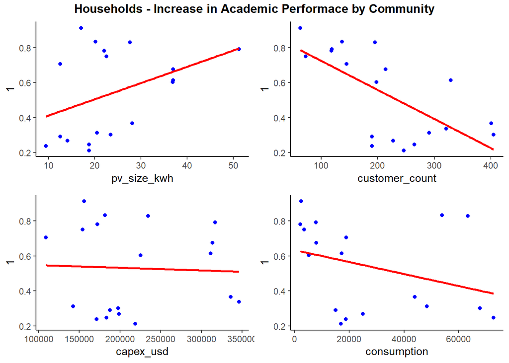

### TODO: C&I Workforce

```r
# Since connection to Renewvia mini-grid, have you had any change in number of workers/employees at your place of work?
```

# 3- Health

## A) Descriptive

### Water Source

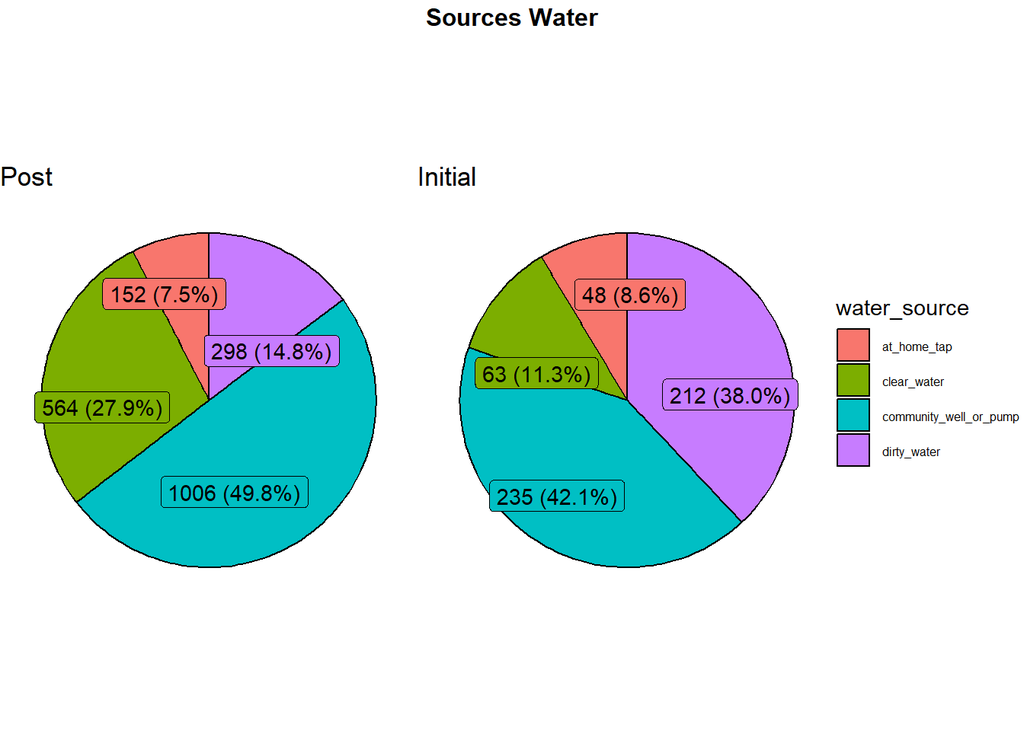

```r
# What is your source of water?
compare_pre_post(var_name="water_source", var_type="non_cont",
                 subplot_type="pie", title="Sources Water")
```

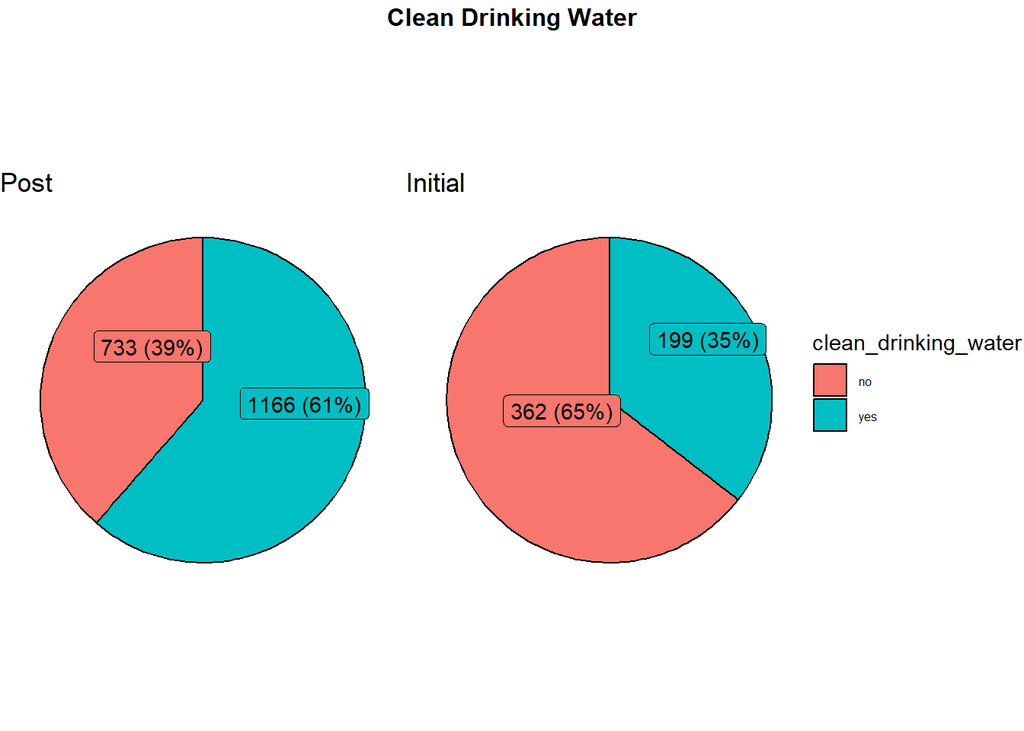

```r
# Do you have a source for clean drinking water?
compare_pre_post(var_name="clean_drinking_water", var_type="non_cont",
                 subplot_type="pie", title="Clean Drinking Water")
```

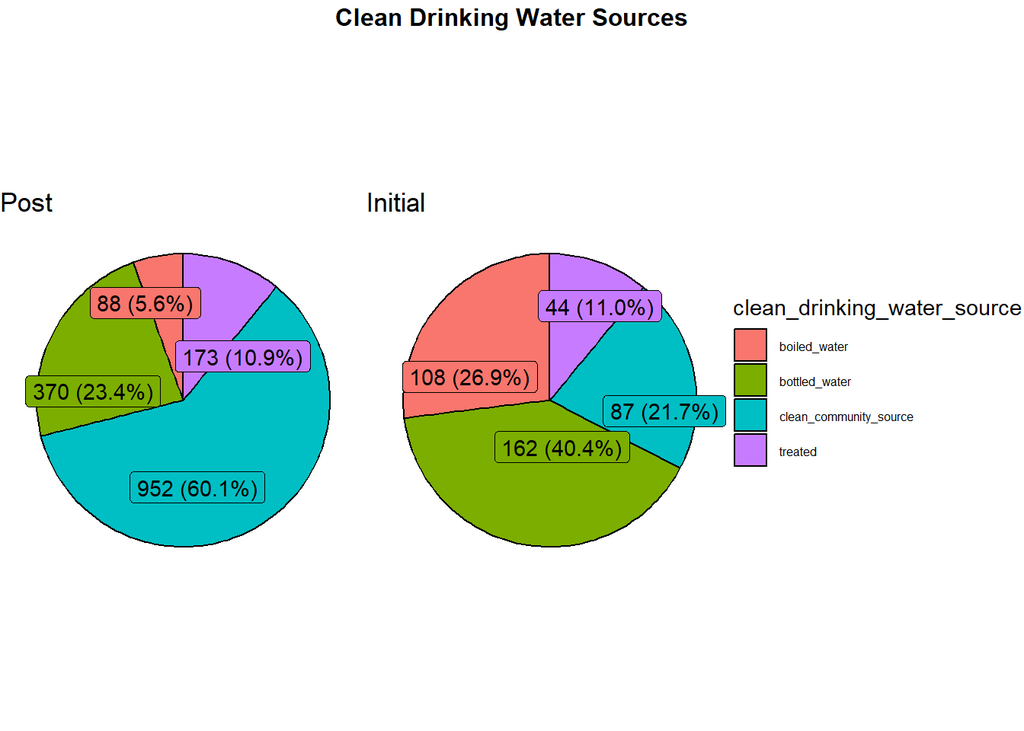

```r
# What is the source for clean drinking water?
compare_pre_post(var_name="clean_drinking_water_source", var_type="non_cont",
                 subplot_type="pie", title="Clean Drinking Water Sources")
```

### Kerosene Lamps

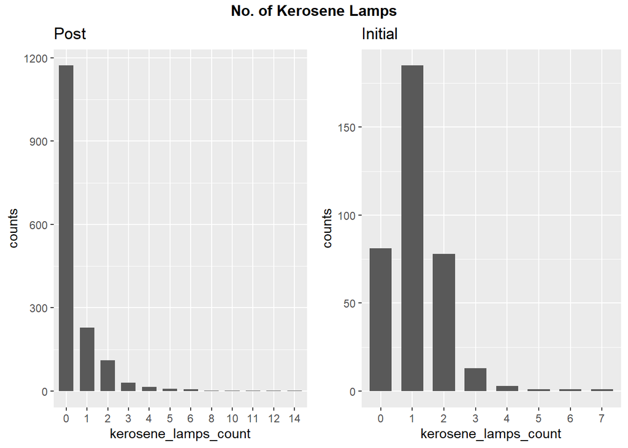

```r
# How many kerosene lamps do you currently have in your household?
compare_pre_post(var_name="kerosene_lamps_count", var_type="non_cont",
                 subplot_type="bar_discrete", title="No. of Kerosene Lamps",
                 char_remove=c(24))
```

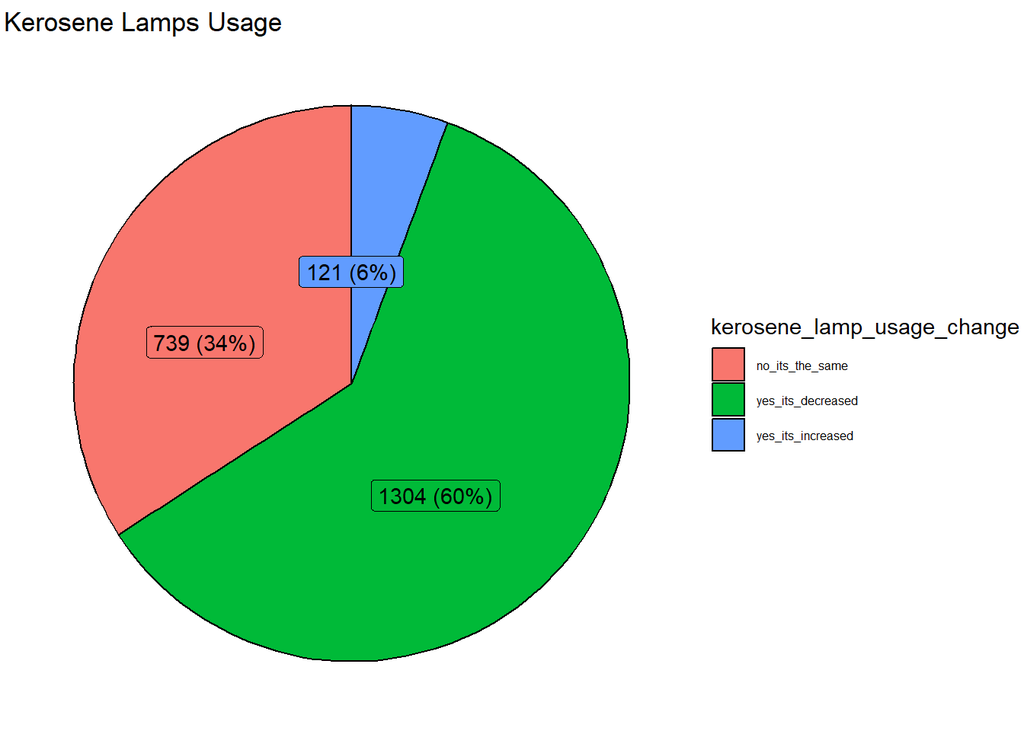

```r
# Has the number of kerosene lamps in your household changed since connection to minigrid?
plot_func(df=post_clean, var_name="kerosene_lamp_usage_change",
          var_type="non_cont", plot_title="Kerosene Lamps Usage",
          plot_type="pie", char_remove=NULL)
```

### Healthcare

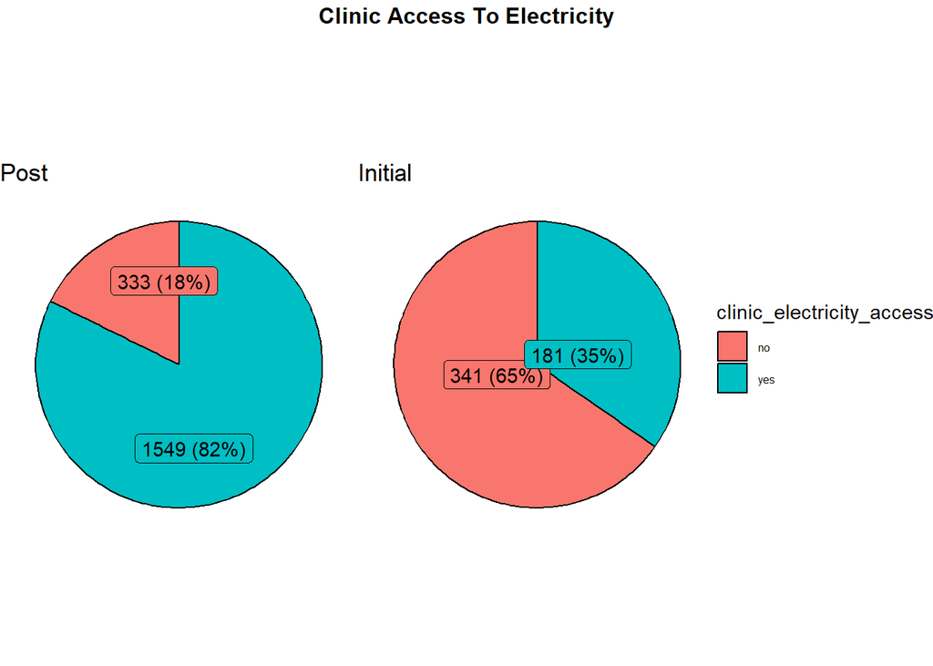

```r
# # Does your Health Center have access to electricity?
compare_pre_post(var_name="clinic_electricity_access", var_type="non_cont",
                 subplot_type="pie", title="Clinic Access To Electricity",
                 char_remove=NULL)
```

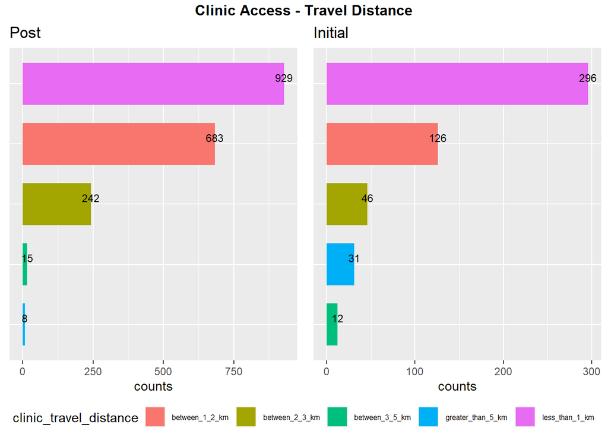

```r
# How close is the nearest Health Center / Clinic
compare_pre_post(var_name="clinic_travel_distance", var_type="non_cont",
                 subplot_type="bar", title="Clinic Access - Travel Distance",
                 char_remove=NULL)
```

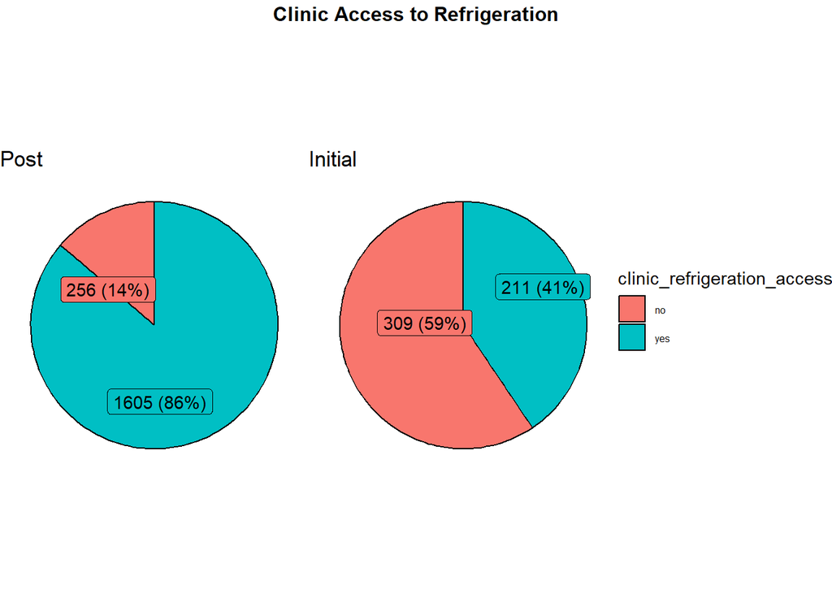

```r
# Does your Health Center / Clinic have access to refrigeration?
compare_pre_post(var_name="clinic_refrigeration_access", var_type="non_cont",
                 subplot_type="pie", title="Clinic Access to Refrigeration")
```

### TODO: New Columns for each type

```r
# What services are you able to offer/sell/provide due to connection to Renewvia minigrid that you werent able to offer prior to connection?
```

```r
# What is the Clinic / Hospital able to offer or provide due to connection to Renewvia minigrid that it wasnt able to offer before?
```

## B) Inferential

### Access to clean drinking water

**Data Source**: Paired Household Surveys (Pre & Post)

**Value (Encoding if applied)**: “yes” = 1; “no” = 0

```r
## Do you have a source for clean drinking water? ## McNemar's  Test
paired_testing(paired_enc, var_name="clean_drinking_water",
               test_type = "mcnemar", plot_diff=FALSE)
```

```
##        var_post
## var_pre   0   1
##       0 191 115
##       1  61  88
```

```
##
##  McNemar's Chi-squared test with continuity correction
##
## data:  cross_tab
## McNemar's chi-squared = 15.96, df = 1, p-value = 0.00006469
```

### Clean drinking water access - change

**Value (Encoding if applied)**: “Yes, it’s decreased” = -1; “No, it’s the same” = 0; “Yes, it’s increased” = 1

```r
## Since connection to Renewvia mini-grid, has your access to clean drinking water changed at all?
community_reg(df=post_enc,
              col_name="clean_drinking_water_source", dep="1", var_type="categorical",
              title="Increase in Access to Clean Drinking Water by Community")
```

```
## [1] "pv_size_kwh"
##                   Estimate   Std. Error    t value   Pr(>|t|)
## Intercept    0.08275612448 0.0354169456  2.3366251 0.03195675
## pv_size_kwh -0.00005882579 0.0002775557 -0.2119423 0.83467227
##                              2.5 %       97.5 %
## (Intercept)            0.008032901 0.1574793480
## community_data[, ind] -0.000644417 0.0005267655
## [1] "customer_count"
##                      Estimate    Std. Error    t value   Pr(>|t|)
## Intercept       0.08730474195 0.03783623477  2.3074374 0.03388001
## customer_count -0.00002146478 0.00005604306 -0.3830051 0.70646288
##                               2.5 %        97.5 %
## (Intercept)            0.0074772644 0.16713221947
## community_data[, ind] -0.0001397053 0.00009677574
## [1] "capex_usd"
##                   Estimate      Std. Error    t value  Pr(>|t|)
## Intercept  0.0843682315026 0.0568319214518  1.4845219 0.1559763
## capex_usd -0.0000000181779 0.0000001790117 -0.1015459 0.9203052
##                                  2.5 %          97.5 %
## (Intercept)           -0.0355366416946 0.2042731046999
## community_data[, ind] -0.0000003958596 0.0000003595038
## [1] "consumption"
##                     Estimate      Std. Error    t value  Pr(>|t|)
## Intercept    0.0981942853607 0.0383062651487  2.5634001 0.0201462
## consumption -0.0000003685449 0.0000004313465 -0.8544058 0.4047602
##                                 2.5 %          97.5 %
## (Intercept)            0.017375130421 0.1790134403000
## community_data[, ind] -0.000001278606 0.0000005415166
```

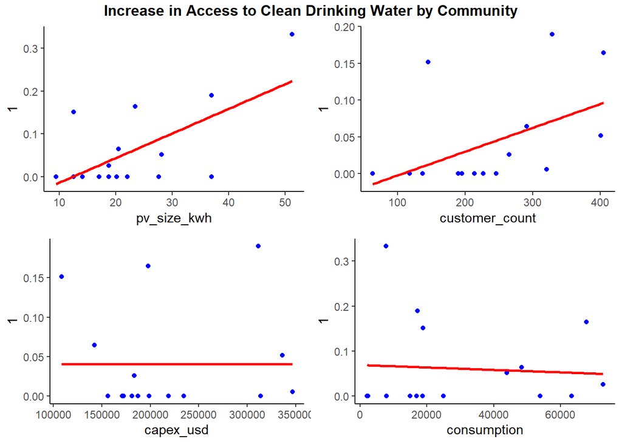

### Kerosene Lamps Count*

**Data Source**: Paired Household Surveys (Pre & Post)

**Value (Encoding if applied)**: Any numeric value

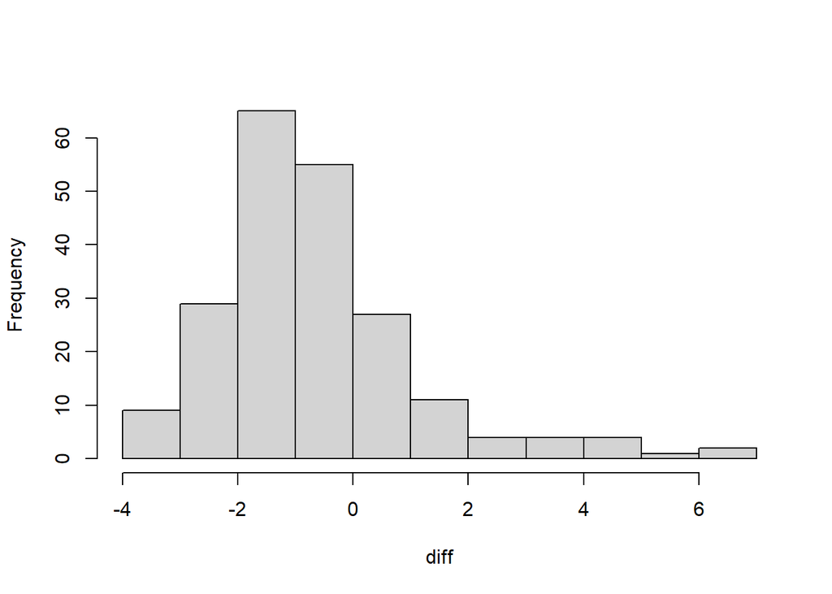

```
##
##  Paired t-test
##
## data:  var_pre and var_post
## t = 1.3119, df = 210, p-value = 0.191
## alternative hypothesis: true mean difference is not equal to 0
## 95 percent confidence interval:
##  -0.08100167  0.40327655
## sample estimates:
## mean difference
##       0.1611374
```

```r
## How many kerosene lamps do you currently use in your household?
paired_testing(paired_enc, var_name="kerosene_lamps_count",
               test_type = "ttest", plot_diff=TRUE)
```

```r
community_reg(df=paired_enc, calc_diff = TRUE,
              col_name="kerosene_lamps_count", dep="V1",
              title="Difference in No. of Kerosene Lamps by Community",
              var_type="ratio")
```

```
## [1] "pv_size_kwh"
##                Estimate Std. Error    t value  Pr(>|t|)
## Intercept   -2.88459281 7.34336177 -0.3928164 0.7008206
## pv_size_kwh  0.01012031 0.05141875  0.1968215 0.8470110
##                             2.5 %     97.5 %
## (Intercept)           -18.7489614 12.9797758
## community_data[, ind]  -0.1009631  0.1212038
## [1] "customer_count"
##                    Estimate Std. Error    t value  Pr(>|t|)
## Intercept      -3.153803277 7.91936195 -0.3982396 0.6969168
## customer_count  0.002156035 0.01049823  0.2053712 0.8404630
##                              2.5 %      97.5 %
## (Intercept)           -20.26254460 13.95493805
## community_data[, ind]  -0.02052402  0.02483609
## [1] "capex_usd"
##                 Estimate     Std. Error    t value  Pr(>|t|)
## Intercept -6.59910907783 11.29813637664 -0.5840883 0.5691581
## capex_usd  0.00001574719  0.00003335105  0.4721649 0.6446367
##                                 2.5 %         97.5 %
## (Intercept)           -31.00724878236 17.80903062670
## community_data[, ind]  -0.00005630337  0.00008779775
## [1] "consumption"
##                   Estimate    Std. Error    t value  Pr(>|t|)
## Intercept   -3.09202926791 8.18587998403 -0.3777272 0.7117286
## consumption  0.00001439378 0.00008347205  0.1724383 0.8657486
##                                2.5 %        97.5 %
## (Intercept)           -20.7765478110 14.5924892751
## community_data[, ind]  -0.0001659366  0.0001947242
```

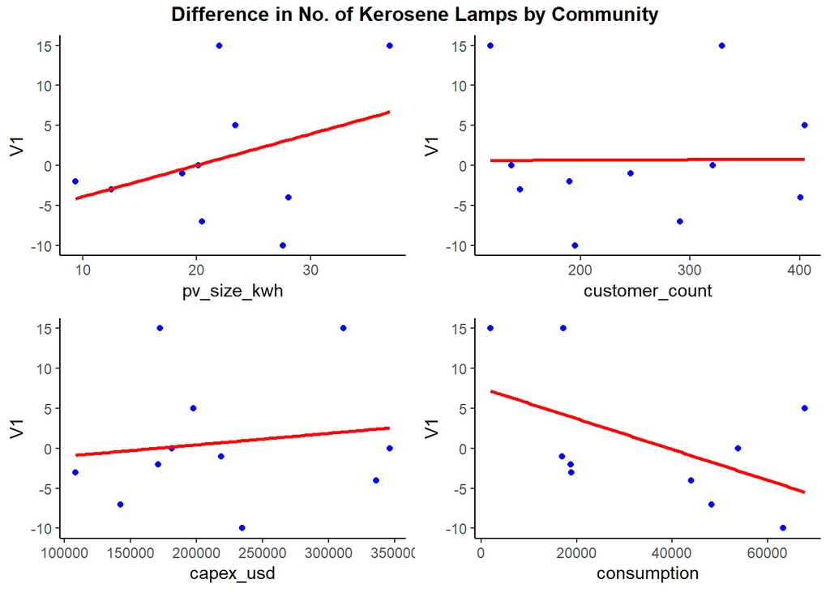

```r
consumption_reg(df = paired_enc, reg_type ="linear",
                dep= "kerosene_lamps_count", calc_diff=TRUE,
                title="Energy Consumption vs. Difference in No. of Kerosene Lamps")
```

```
##
## Call:
## lm(formula = df$col_reg ~ df$Energy.Consumption)
##
## Residuals:
##     Min      1Q  Median      3Q     Max
## -3.8252 -0.8422  0.1572  0.6690  7.1603
##
## Coefficients:
##                         Estimate Std. Error t value Pr(>|t|)
## (Intercept)           -0.1569639  0.1313410  -1.195    0.233
## df$Energy.Consumption -0.0001167  0.0012786  -0.091    0.927
##
## Residual standard error: 1.788 on 209 degrees of freedom
##   (258 observations deleted due to missingness)
## Multiple R-squared:  3.985e-05,  Adjusted R-squared:  -0.004745
## F-statistic: 0.008328 on 1 and 209 DF,  p-value: 0.9274
##
##                              2.5 %      97.5 %
## (Intercept)           -0.415886947 0.101959058
## df$Energy.Consumption -0.002637367 0.002403995
```

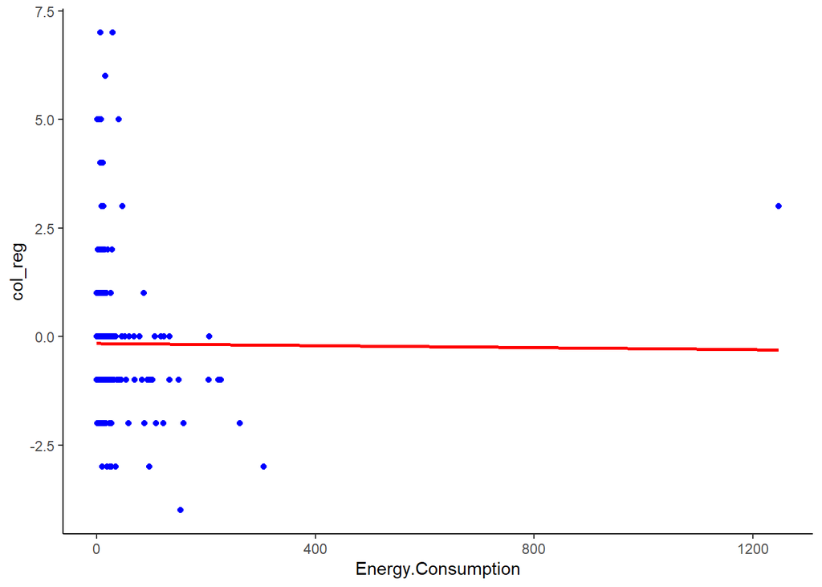

### Kerosene Lamps Usage

**Data Source**: Household Post Survey

**Value (Encoding if applied)**: “Yes, it’s decreased” = -1; “No, it’s the same” = 0; “Yes, it’s increased” = 1

```r
community_reg(df=post_enc,
              col_name="kerosene_lamp_usage_change", dep="-1",
              var_type="categorical",
              title="Decrease in Lamps Water by Community")
```

```
## [1] "pv_size_kwh"
##                 Estimate   Std. Error   t value       Pr(>|t|)
## Intercept    0.620515813 0.0866331580  7.162567 0.000001140144
## pv_size_kwh -0.001128733 0.0006959953 -1.621754 0.122240825516
##                              2.5 %      97.5 %
## (Intercept)            0.438506302 0.802525325
## community_data[, ind] -0.002590965 0.000333499
## [1] "customer_count"
##                     Estimate   Std. Error   t value       Pr(>|t|)
## Intercept       0.6231671708 0.0949594825  6.562453 0.000003636577
## customer_count -0.0001779287 0.0001442636 -1.233358 0.233306475864
##                               2.5 %      97.5 %
## (Intercept)            0.4236647011 0.822669640
## community_data[, ind] -0.0004810153 0.000125158
## [1] "capex_usd"
##                   Estimate      Std. Error   t value      Pr(>|t|)
## Intercept  0.7512225182914 0.1381567071627  5.437467 0.00003638208
## capex_usd -0.0000007386867 0.0000004437409 -1.664680 0.11328654214
##                                 2.5 %          97.5 %
## (Intercept)            0.460966047206 1.0414789893766
## community_data[, ind] -0.000001670952 0.0000001935783
## [1] "consumption"
##                     Estimate     Std. Error    t value       Pr(>|t|)
## Intercept    0.6086890670814 0.099413027724  6.1228300 0.000008771971
## consumption -0.0000009724038 0.000001148471 -0.8466941 0.408282092348
##                                 2.5 %         97.5 %
## (Intercept)            0.399830046048 0.817548088115
## community_data[, ind] -0.000003385252 0.000001440445
```

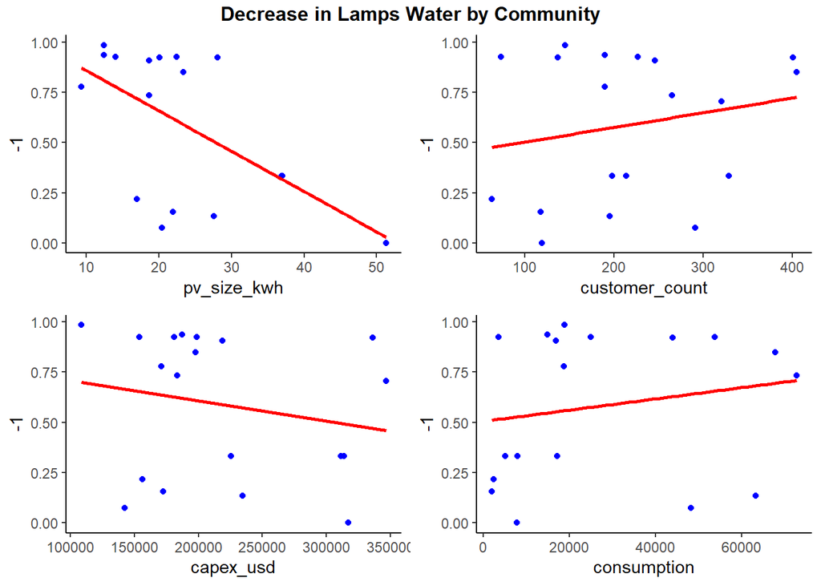

### New Health Services

**Data Source**: Commercial & Institution Post Survey

**Value (Encoding if applied)**: Any value

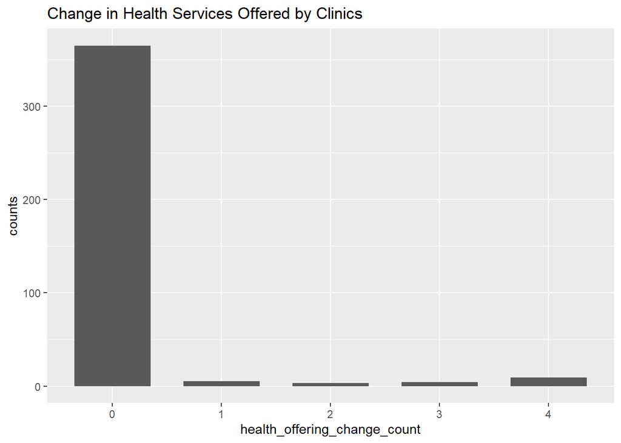

```r
plot_func(df=ci_clean, var_name="health_offering_change_count",
          var_type="non_cont", plot_title="Change in Health Services Offered by Clinics",
          plot_type="bar_discrete", char_remove=NULL)
```

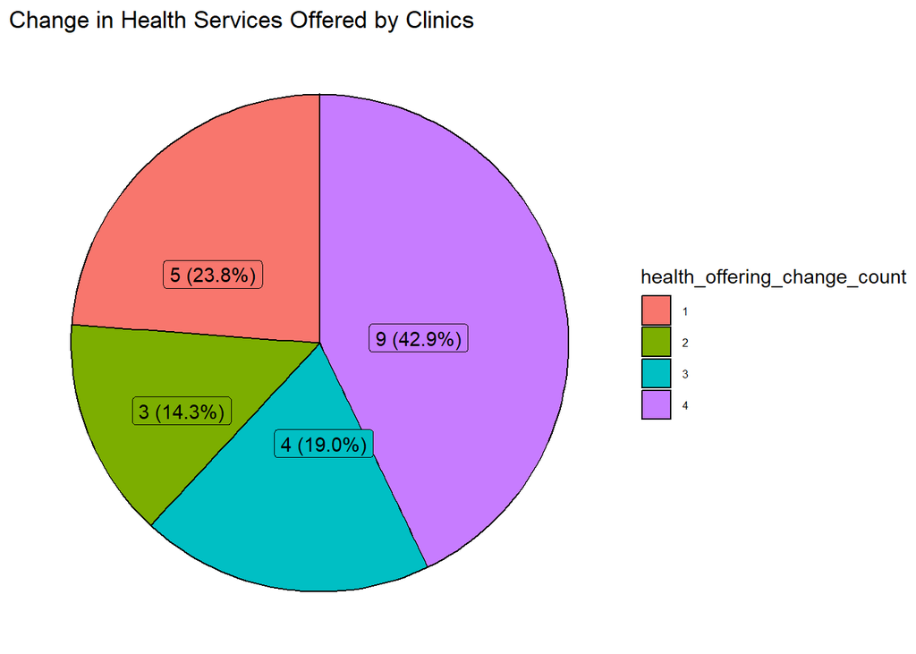

```r
plot_func(df=ci_clean, var_name="health_offering_change_count",
          var_type="non_cont", plot_title="Change in Health Services Offered by Clinics",
          plot_type="pie", char_remove=c(0))
```

```r
## For clinics or health services only: Since connection to Renewvia mini-grid, have your health service offerings changed in any of the following ways: (select all that apply).
community_reg(df=ci_enc,
              col_name="health_offering_change_count", dep="V1",
              title="New Health Services Offered by Community",
              var_type="ratio")
```

```
## [1] "pv_size_kwh"
##               Estimate  Std. Error  t value   Pr(>|t|)
## Intercept   2.21210216 0.936423600 2.362288 0.03317675
## pv_size_kwh 0.01643606 0.006750167 2.434911 0.02886930
##                             2.5 %     97.5 %
## (Intercept)           0.203673290 4.22053103
## community_data[, ind] 0.001958389 0.03091373
## [1] "customer_count"
##                   Estimate  Std. Error  t value   Pr(>|t|)
## Intercept      2.064770795 1.027429838 2.009647 0.06414904
## customer_count 0.002996442 0.001418197 2.112853 0.05305526
##                                2.5 %      97.5 %
## (Intercept)           -0.13884704478 4.268388635
## community_data[, ind] -0.00004528776 0.006038171
## [1] "capex_usd"
##                 Estimate    Std. Error   t value   Pr(>|t|)
## Intercept 0.605411547392 1.57799836319 0.3836579 0.70699539
## capex_usd 0.000009267068 0.00000467126 1.9838478 0.06723641
##                                  2.5 %        97.5 %
## (Intercept)           -2.7790583355238 3.98988143031
## community_data[, ind] -0.0000007517875 0.00001928592
## [1] "consumption"
##                  Estimate    Std. Error  t value   Pr(>|t|)
## Intercept   2.16746414810 1.11079723062 1.951269 0.07132865
## consumption 0.00001943191 0.00001175335 1.653308 0.12050792
##                                 2.5 %        97.5 %
## (Intercept)           -0.214958965102 4.54988726131
## community_data[, ind] -0.000005776515 0.00004464033
```

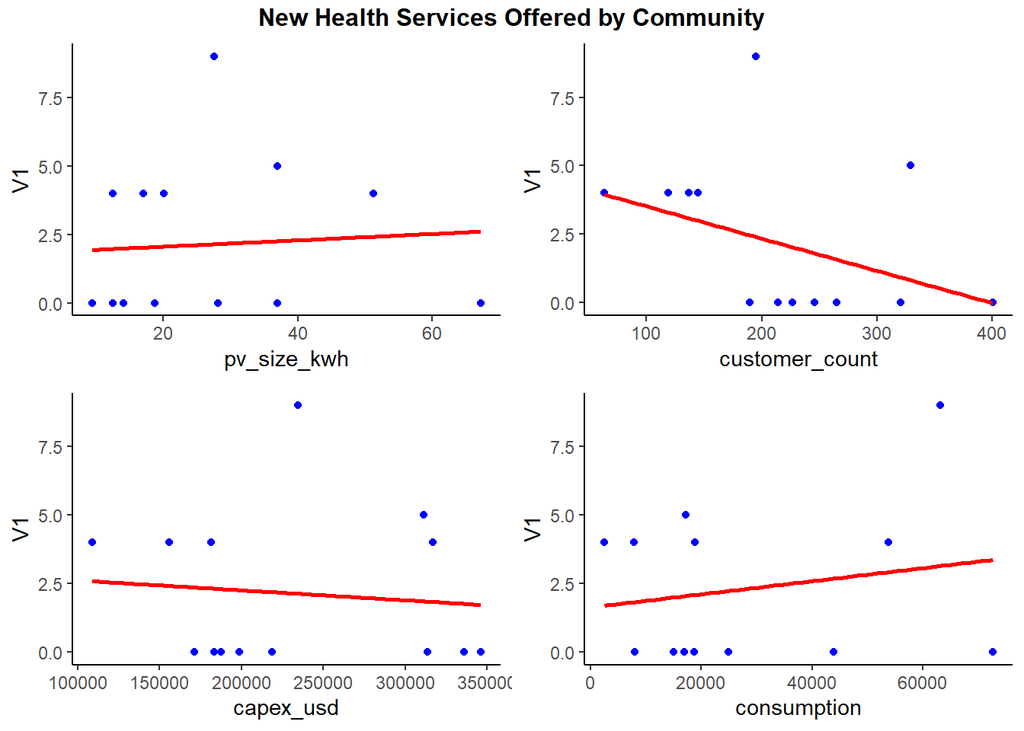

```r
sub <- ci_enc %>% filter(health_offering_change_count != 0)
consumption_reg(df = sub, reg_type ="linear",
                dep= "health_offering_change_count", calc_diff=FALSE,
                title="Energy Consumption vs. New Health Services Offered")
```

```
##
## Call:
## lm(formula = df$col_reg ~ df$Energy.Consumption)
##
## Residuals:
##     Min      1Q  Median      3Q     Max
## -1.7261 -0.6662  0.3279  1.3262  1.3354
##
## Coefficients:
##                         Estimate Std. Error t value     Pr(>|t|)
## (Intercept)           2.66449854 0.28465510   9.360 0.0000000151 ***
## df$Energy.Consumption 0.00011836 0.00008291   1.428         0.17
## ---
## Signif. codes:  0 '***' 0.001 '**' 0.01 '*' 0.05 '.' 0.1 ' ' 1
##
## Residual standard error: 1.219 on 19 degrees of freedom
## Multiple R-squared:  0.09686,    Adjusted R-squared:  0.04933
## F-statistic: 2.038 on 1 and 19 DF,  p-value: 0.1697
##
##                                2.5 %       97.5 %
## (Intercept)            2.06870857112 3.2602885165
## df$Energy.Consumption -0.00005517794 0.0002918907
```

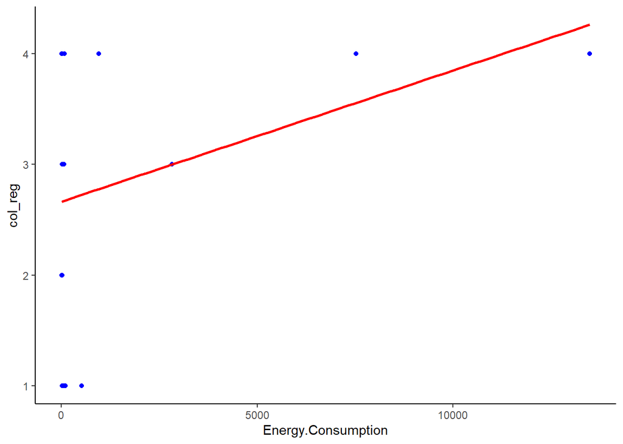

### Clinic Access To Electricity

**Data Source**: Paired Household Surveys (Pre & Post)

**Value (Encoding if applied)**: “yes” = 1; “no” = 0

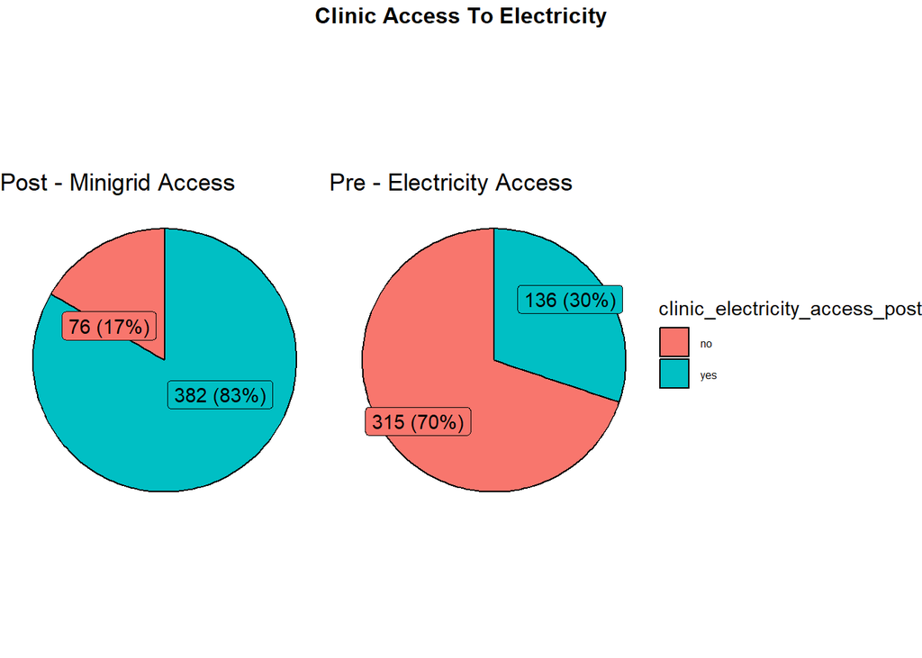

```r
compare_in_df(data=paired_clean, var_type="non_cont",
               var1="clinic_electricity_access_pre",
               var2="clinic_electricity_access_post",
               var1_title="Pre - Electricity Access", var2_title="Post - Minigrid Access",
               subplot_type="pie", plot_title="Clinic Access To Electricity")
```

```r
paired_testing(paired_enc, var_name="clinic_electricity_access",
               test_type = "mcnemar", plot_diff=FALSE)
```

```
##        var_post
## var_pre   0   1
##       0  74 235
##       1   2 133
```

```
##
##  McNemar's Chi-squared test with continuity correction
##
## data:  cross_tab
## McNemar's chi-squared = 227.11, df = 1, p-value < 0.00000000000000022
```

```r
community_reg(df=paired_enc,
              col_name="clinic_electricity_access", dep="1",
              title="Clinic Access To Electricity",
              var_type="categorical", calc_diff = TRUE)
```

```
## [1] "pv_size_kwh"
##                  Estimate   Std. Error    t value   Pr(>|t|)
## Intercept    0.3477187287 0.1585067574  2.1937155 0.06432499
## pv_size_kwh -0.0006905511 0.0008694516 -0.7942375 0.45313710
##                              2.5 %      97.5 %
## (Intercept)           -0.027090194 0.722527651
## community_data[, ind] -0.002746477 0.001365375
## [1] "customer_count"
##                     Estimate   Std. Error    t value   Pr(>|t|)
## Intercept       0.3480799962 0.1717412543  2.0267699 0.08230412
## customer_count -0.0001105957 0.0001809626 -0.6111521 0.56041295
##                               2.5 %      97.5 %
## (Intercept)           -0.0580235386 0.754183531
## community_data[, ind] -0.0005385044 0.000317313
## [1] "capex_usd"
##                   Estimate      Std. Error    t value  Pr(>|t|)
## Intercept  0.4243122192734 0.2431361102571  1.7451633 0.1244681
## capex_usd -0.0000004127754 0.0000006073635 -0.6796184 0.5185809
##                                 2.5 %         97.5 %
## (Intercept)           -0.150613323479 0.999237762025
## community_data[, ind] -0.000001848962 0.000001023411
## [1] "consumption"
##                     Estimate    Std. Error    t value  Pr(>|t|)
## Intercept    0.3291515185087 0.16376458867  2.0099065 0.0843774
## consumption -0.0000007537957 0.00000149319 -0.5048222 0.6291846
##                                2.5 %         97.5 %
## (Intercept)           -0.05809019941 0.716393236427
## community_data[, ind] -0.00000428463 0.000002777038
```

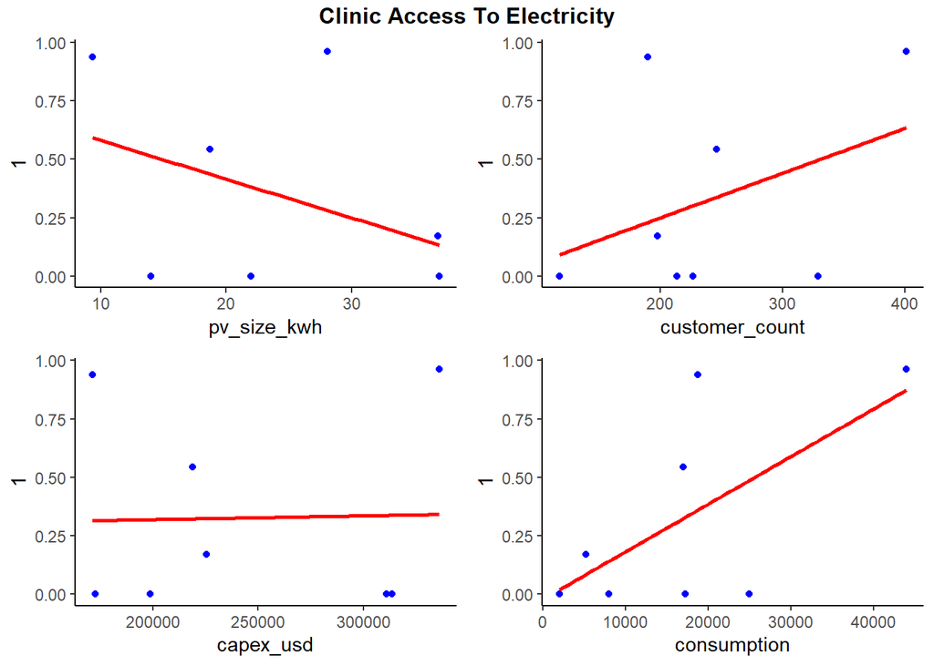

### Clinic Access To Refrigeration

**Data Source**: Paired Household Surveys (Pre & Post)

**Value (Encoding if applied)**: “yes” = 1; “no” = 0

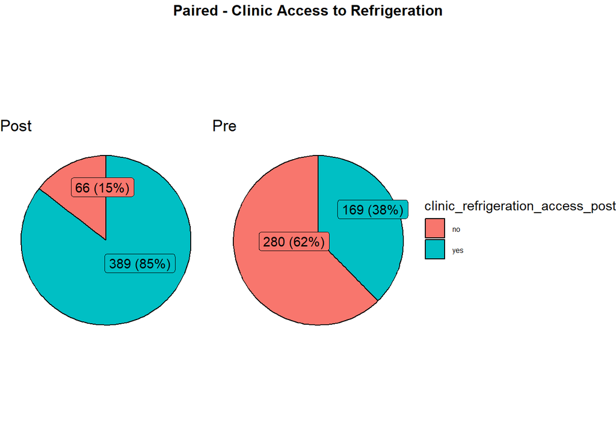

```r
compare_in_df(data=paired_clean, var_type="non_cont",
               var1="clinic_refrigeration_access_pre",
               var2="clinic_refrigeration_access_post",
               var1_title="Pre", var2_title="Post",
               subplot_type="pie", plot_title="Paired - Clinic Access to Refrigeration")
```

```r
## Does your Health Center / Clinic have access to refrigeration?
## McNemar's  Test
paired_testing(paired_enc, var_name="clinic_refrigeration_access",
               test_type = "mcnemar", plot_diff=FALSE)
```

```
##        var_post
## var_pre   0   1
##       0  47 227
##       1  19 147
```

```
##
##  McNemar's Chi-squared test with continuity correction
##
## data:  cross_tab
## McNemar's chi-squared = 174.18, df = 1, p-value < 0.00000000000000022
```

```r
community_reg(df=paired_enc,
              col_name="clinic_refrigeration_access", dep="1",
              title="Clinic Access To Refrigeration",
              var_type="categorical", calc_diff = TRUE)
```

```
## [1] "pv_size_kwh"
##                 Estimate   Std. Error    t value   Pr(>|t|)
## Intercept    0.447045268 0.1708709874  2.6162737 0.03459616
## pv_size_kwh -0.000862862 0.0009372727 -0.9206093 0.38788000
##                             2.5 %      97.5 %
## (Intercept)            0.04299959 0.851090949
## community_data[, ind] -0.00307916 0.001353436
## [1] "customer_count"
##                     Estimate   Std. Error    t value   Pr(>|t|)
## Intercept       0.4624771230 0.1831427306  2.5252278 0.03950749
## customer_count -0.0001670131 0.0001929763 -0.8654592 0.41546016
##                               2.5 %       97.5 %
## (Intercept)            0.0294133809 0.8955408652
## community_data[, ind] -0.0006233296 0.0002893033
## [1] "capex_usd"
##                   Estimate      Std. Error   t value  Pr(>|t|)
## Intercept  0.5964815563820 0.2543091344165  2.345498 0.0514271
## capex_usd -0.0000006816364 0.0000006352742 -1.072980 0.3188709
##                                 2.5 %          97.5 %
## (Intercept)           -0.004863990261 1.1978271030248
## community_data[, ind] -0.000002183821 0.0000008205483
## [1] "consumption"
##                    Estimate     Std. Error    t value   Pr(>|t|)
## Intercept    0.442527407884 0.174017199756  2.5430096 0.03849446
## consumption -0.000001307134 0.000001586673 -0.8238207 0.43720616
##                                 2.5 %         97.5 %
## (Intercept)            0.031042117147 0.854012698620
## community_data[, ind] -0.000005059019 0.000002444751
```

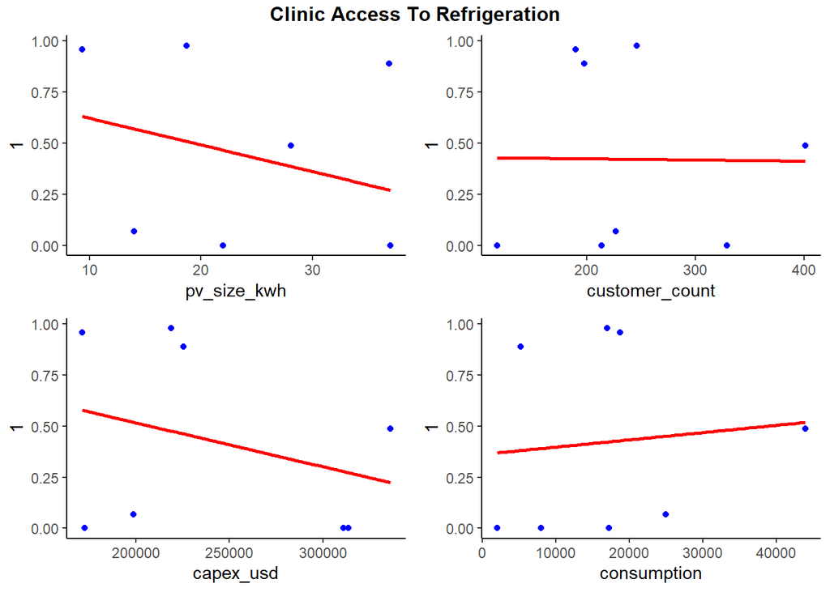

### Better access to healthcare

**Data Source**: Household Post-Survey

**Value (Encoding if applied)**: “yes” = 1; “no” = 0

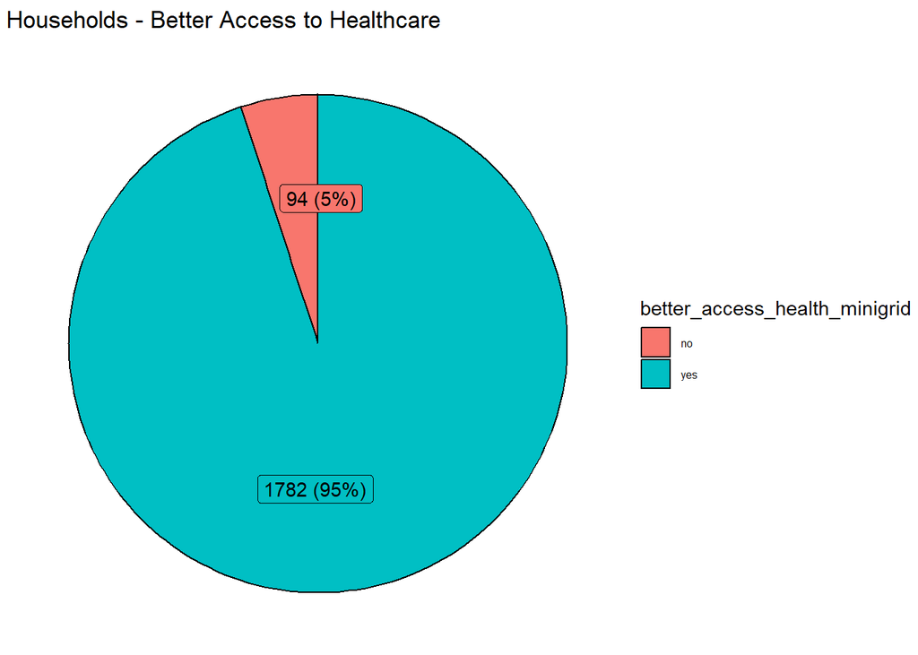

```r
## Do you feel that you have better access to health services because of connection to mini-grid?
plot_func(df=post_clean, var_name="better_access_health_minigrid",
          var_type="non_cont", plot_title="Households - Better Access to Healthcare",
          plot_type="pie")
```

```
## [1] "pv_size_kwh"
##                   Estimate   Std. Error    t value
## Intercept    0.95846930129 0.0171665618 55.8335043
## pv_size_kwh -0.00007820363 0.0001379131 -0.5670502
##                                  Pr(>|t|)
## Intercept   0.000000000000000000001259623
## pv_size_kwh 0.577683901623011530901408150
##                               2.5 %      97.5 %
## (Intercept)            0.9224036933 0.994534909
## community_data[, ind] -0.0003679483 0.000211541
## [1] "customer_count"
##                      Estimate   Std. Error    t value
## Intercept       0.96352319976 0.0180036722 53.5181484
## customer_count -0.00002648114 0.0000273514 -0.9681819
##                                     Pr(>|t|)
## Intercept      0.000000000000000000002688098
## customer_count 0.345783575595092318444301327
##                               2.5 %        97.5 %
## (Intercept)            0.9256988881 1.00134751146
## community_data[, ind] -0.0000839443 0.00003098203
## [1] "capex_usd"
##                    Estimate     Std. Error    t value
## Intercept  0.96685428981460 0.027483709332 35.1791775
## capex_usd -0.00000004856104 0.000000088274 -0.5501171
##                             Pr(>|t|)
## Intercept 0.000000000000000004774912
## capex_usd 0.589001082982818724431695
##                                  2.5 %          97.5 %
## (Intercept)            0.9091131591319 1.0245954204973
## community_data[, ind] -0.0000002340178 0.0000001368958
## [1] "consumption"
##                     Estimate      Std. Error   t value
## Intercept    0.9653575825056 0.0183512105794 52.604572
## consumption -0.0000002277028 0.0000002120028 -1.074056
##                                  Pr(>|t|)
## Intercept   0.000000000000000000003657879
## consumption 0.296985570208328775176909176
##                                  2.5 %          97.5 %
## (Intercept)            0.9268031197342 1.0039120452769
## community_data[, ind] -0.0000006731041 0.0000002176985
```

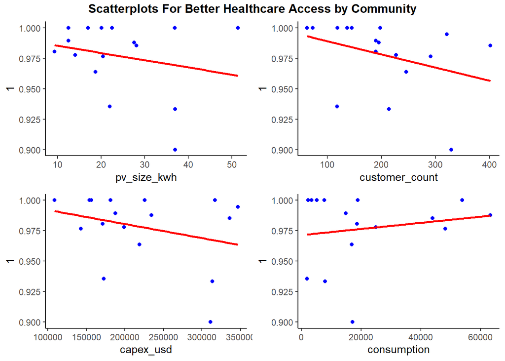

```r
community_reg(df=post_enc,
              col_name="better_access_health_minigrid", dep="1", var_type="categorical",
              title="Scatterplots For Better Healthcare Access by Community")
```

```r
consumption_reg(df = post_enc, reg_type ="logistic",
                dep= "better_access_health_minigrid",
                title="Energy Consumption vs. Better Healthcare Access")
```

```
## Wald test:
## ----------
##
## Chi-squared test:
## X2 = 696.1, df = 1, P(> X2) = 0.0
##
## Call:
## glm(formula = df[, dep] ~ df$Energy.Consumption, family = binomial)
##
## Coefficients:
##                         Estimate Std. Error z value            Pr(>|z|)
## (Intercept)            2.9902633  0.1133356  26.384 <0.0000000000000002 ***
## df$Energy.Consumption -0.0004915  0.0004441  -1.107               0.268
## ---
## Signif. codes:  0 '***' 0.001 '**' 0.01 '*' 0.05 '.' 0.1 ' ' 1
##
## (Dispersion parameter for binomial family taken to be 1)
##
##     Null deviance: 739.70  on 1871  degrees of freedom
## Residual deviance: 738.74  on 1870  degrees of freedom
##   (330 observations deleted due to missingness)
## AIC: 742.74
##
## Number of Fisher Scoring iterations: 5
```

```
##                              2.5 %       97.5 %
## (Intercept)            2.773343340 3.2185998392
## df$Energy.Consumption -0.001276383 0.0006371482
```

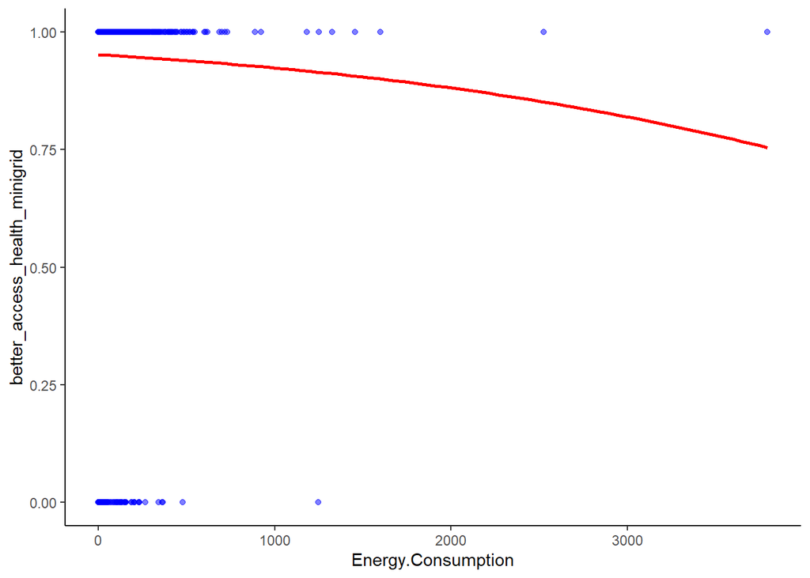

# 4- Safety

## A) Descriptive

### Feeling Safe

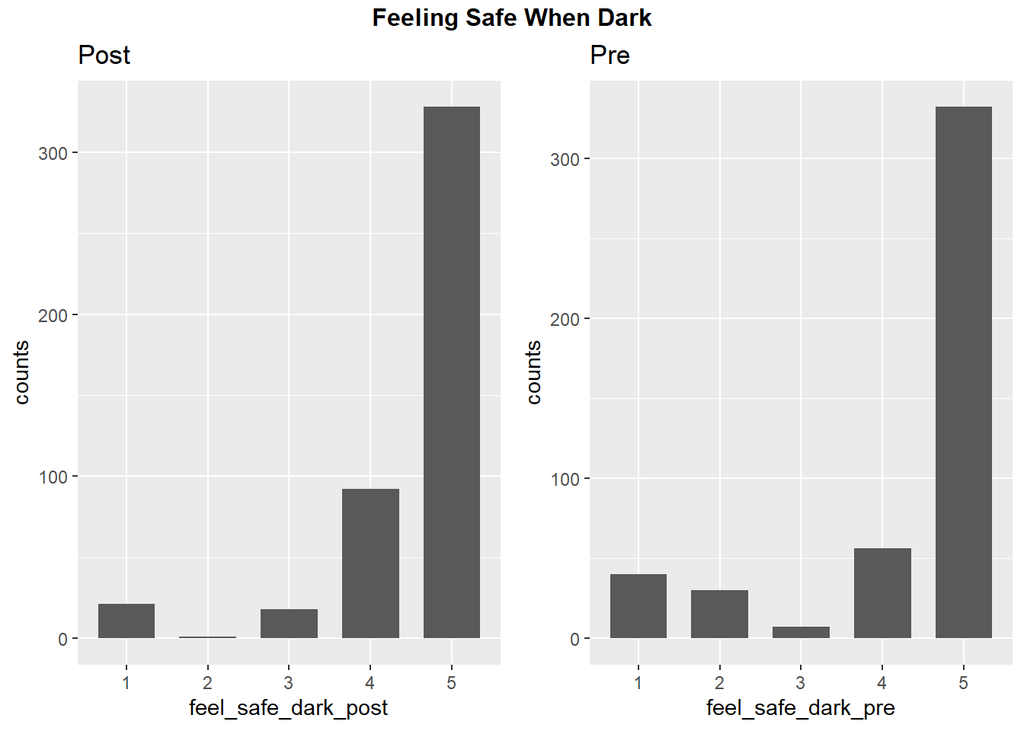

```r
# How safe do you feel outside your home when it is dark?
compare_in_df(data=paired_enc, var_type="non_cont",
               var1="feel_safe_dark_pre",
               var2="feel_safe_dark_post",
               var1_title="Pre", var2_title="Post",
               subplot_type="bar_discrete", plot_title="Feeling Safe When Dark")
```

### Reasons for Feeling Unsafe

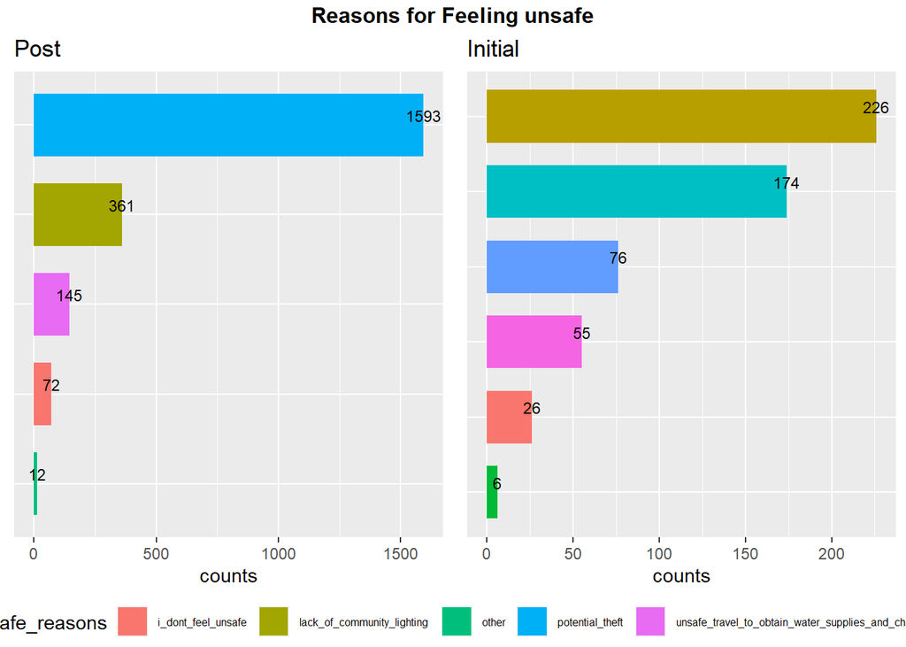

```r
# What makes you feel the most unsafe?
compare_pre_post(var_name="feel_unsafe_reasons", var_type="non_cont",
                 subplot_type="bar", title="Reasons for Feeling unsafe")
```

### Presence of Community Lights

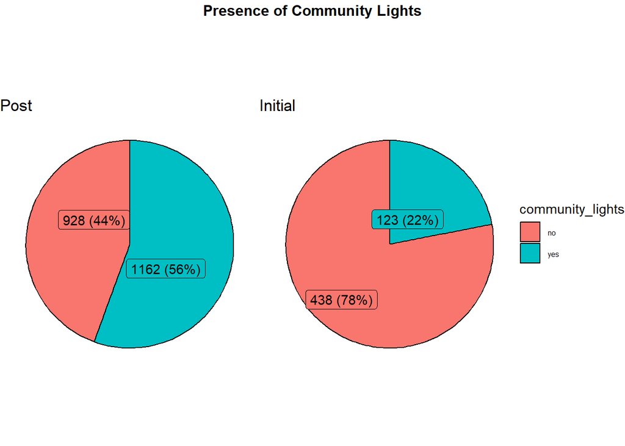

```r
# Does your community currently have outdoor community lights?
compare_pre_post(var_name="community_lights", var_type="non_cont",
                 subplot_type="pie", title="Presence of Community Lights")
```

### Household - Exterior Lights

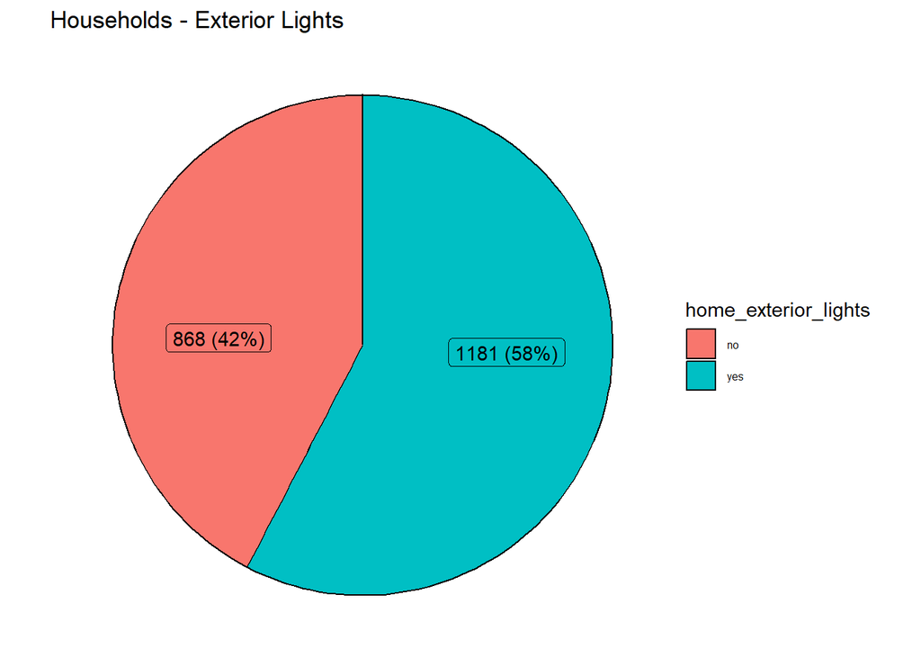

```r
# Does your home have exterior lighting?
plot_func(df=post_clean, var_name="home_exterior_lights",
          var_type="non_cont", plot_title="Households - Exterior Lights",
          plot_type="pie")
```

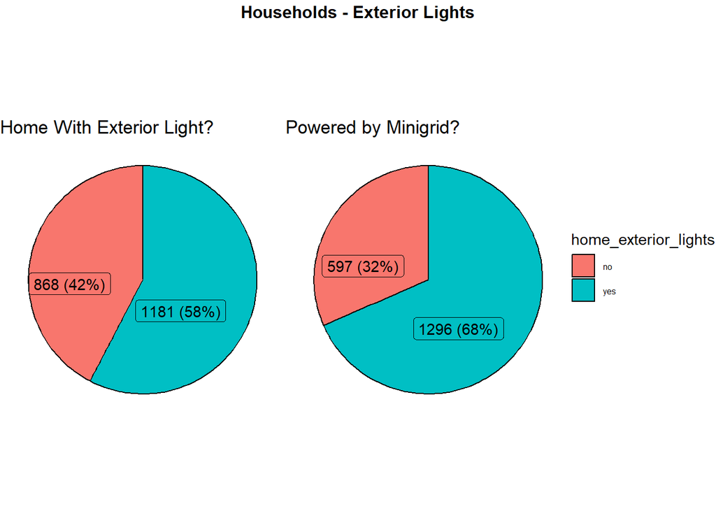

```r
# Is this exterior lighting powered by minigrid?
compare_in_df(data=post_clean, var_type="non_cont",
              var1="exterior_lights_minigrid",
               var2="home_exterior_lights",
               var1_title="Powered by Minigrid?", var2_title="Home With Exterior Light?",
               subplot_type="pie", plot_title="Households - Exterior Lights")
```

## B) Inferential

### Feeling Safe

**Value (Encoding if applied)**: “Very unsafe” = 1; “Somewhat unsafe” = 2; “Neither safe nor unsafe”= 3; “Somewhat safe” = 4; “Very safe” = 5

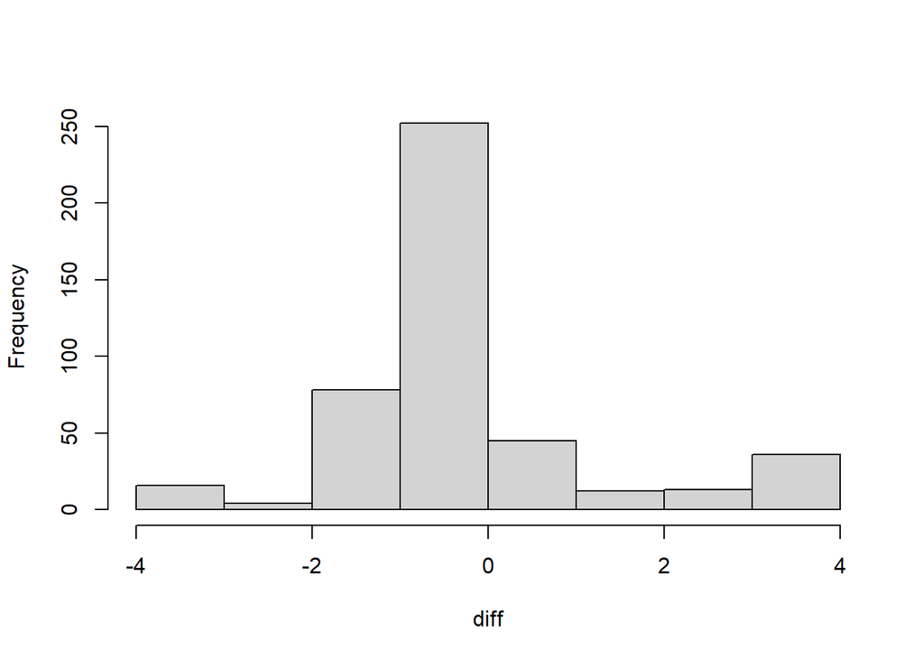

```
##
##  Wilcoxon signed rank test with continuity correction
##
## data:  var_pre and var_post
## V = 8193.5, p-value = 0.005777
## alternative hypothesis: true location shift is not equal to 0
```

```r
# # How safe do you feel outside your home when it is dark?
paired_testing(paired_enc, var_name="feel_safe_dark",
               test_type = "wilcoxon", plot_diff=TRUE)
```

### Reasons for Feeling Unsafe - Potential Theft

```r
# What makes you feel the most unsafe? Testing for Potentiel Theft only
community_reg(df=paired_enc,
              col_name="unsafe_due_to_theft", dep="-1",
              title="Unsafe Due to Theft",
              var_type="categorical", calc_diff = TRUE)
```

```
## [1] "pv_size_kwh"
##                Estimate   Std. Error   t value    Pr(>|t|)
## Intercept    0.35052668 0.0814054196  4.305938 0.000853828
## pv_size_kwh -0.00065024 0.0005700066 -1.140759 0.274550545
##                              2.5 %       97.5 %
## (Intercept)            0.174660961 0.5263923945
## community_data[, ind] -0.001881664 0.0005811844
## [1] "customer_count"
##                     Estimate   Std. Error   t value     Pr(>|t|)
## Intercept       0.3689268249 0.0872246232  4.229618 0.0009837831
## customer_count -0.0001412083 0.0001156286 -1.221223 0.2436873875
##                               2.5 %      97.5 %
## (Intercept)            0.1804894829 0.557364167
## community_data[, ind] -0.0003910086 0.000108592
## [1] "capex_usd"
##                   Estimate      Std. Error    t value    Pr(>|t|)
## Intercept  0.4139435718740 0.1275169740680  3.2461841 0.006374883
## capex_usd -0.0000003748091 0.0000003764182 -0.9957251 0.337557275
##                                 2.5 %          97.5 %
## (Intercept)            0.138459897930 0.6894272458176
## community_data[, ind] -0.000001188011 0.0000004383931
## [1] "consumption"
##                    Estimate      Std. Error   t value     Pr(>|t|)
## Intercept    0.403346389993 0.0844201004400  4.777848 0.0003609058
## consumption -0.000001613524 0.0000008608383 -1.874363 0.0835260136
##                                 2.5 %          97.5 %
## (Intercept)            0.220967851027 0.5857249289587
## community_data[, ind] -0.000003473252 0.0000002462042
```

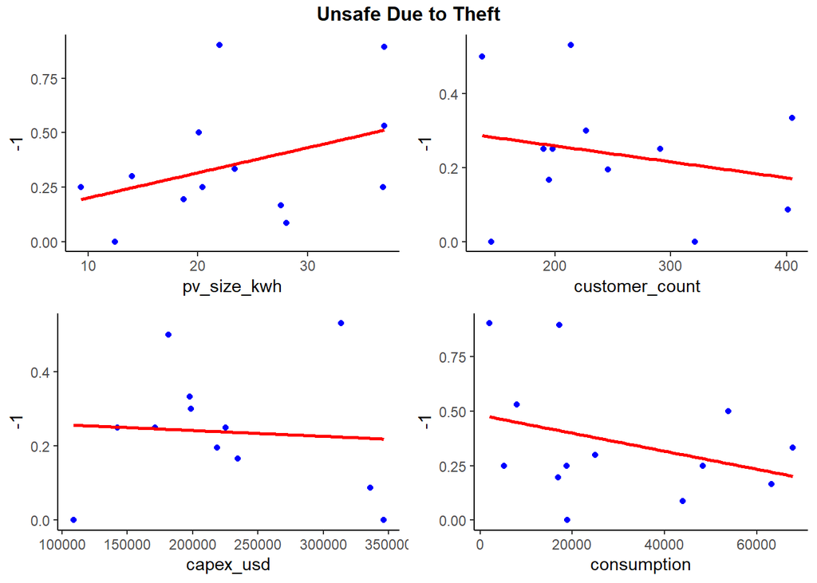

### TODO: Presence of Community Lights

```r
# Does your community currently have outdoor community lights?
paired_testing(paired_enc, var_name="community_lights",
               test_type = "mcnemar", plot_diff=FALSE)
```

```
##        var_post
## var_pre   0   1
##       0 220 147
##       1  84   8
```

```
##
##  McNemar's Chi-squared test with continuity correction
##
## data:  cross_tab
## McNemar's chi-squared = 16.641, df = 1, p-value = 0.00004517
```

```r
community_reg(df=paired_enc,
              col_name="community_lights", dep="1",
              title="Community Lights",
              var_type="categorical", calc_diff = TRUE)
```

```
## [1] "pv_size_kwh"
##                 Estimate  Std. Error   t value    Pr(>|t|)
## Intercept   0.4622154700 0.138033611 3.3485719 0.005795436
## pv_size_kwh 0.0001538928 0.000940742 0.1635866 0.872779420
##                              2.5 %      97.5 %
## (Intercept)            0.161466068 0.762964872
## community_data[, ind] -0.001895808 0.002203594
## [1] "customer_count"
##                      Estimate   Std. Error    t value    Pr(>|t|)
## Intercept      0.470695934672 0.1493495065 3.15164038 0.008349457
## customer_count 0.000002026868 0.0001924356 0.01053271 0.991769353
##                               2.5 %       97.5 %
## (Intercept)            0.1452913138 0.7961005555
## community_data[, ind] -0.0004172544 0.0004213081
## [1] "capex_usd"
##                    Estimate      Std. Error    t value   Pr(>|t|)
## Intercept 0.469693629113145 0.2090079362641 2.24725260 0.04421559
## capex_usd 0.000000006848862 0.0000006179876 0.01108252 0.99133973
##                                2.5 %         97.5 %
## (Intercept)            0.01430445608 0.925082802148
## community_data[, ind] -0.00000133963 0.000001353328
## [1] "consumption"
##                     Estimate     Std. Error    t value    Pr(>|t|)
## Intercept    0.5034645547670 0.149037462906  3.3781074 0.005487326
## consumption -0.0000006272945 0.000001593645 -0.3936224 0.700764181
##                                 2.5 %        97.5 %
## (Intercept)            0.178739818487 0.82818929105
## community_data[, ind] -0.000004099549 0.00000284496
```

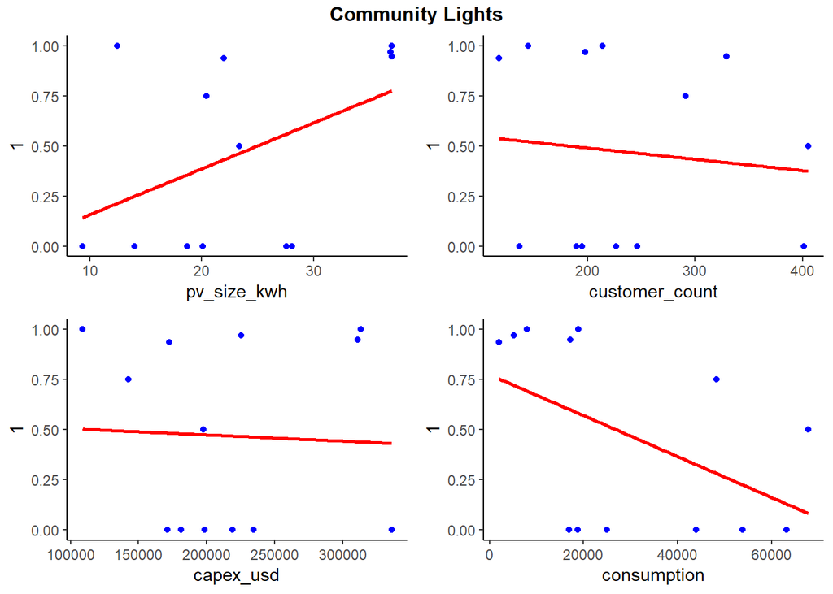

# 5- Economic Activity

## A) Descriptive

### Pre-connection: Employment Type

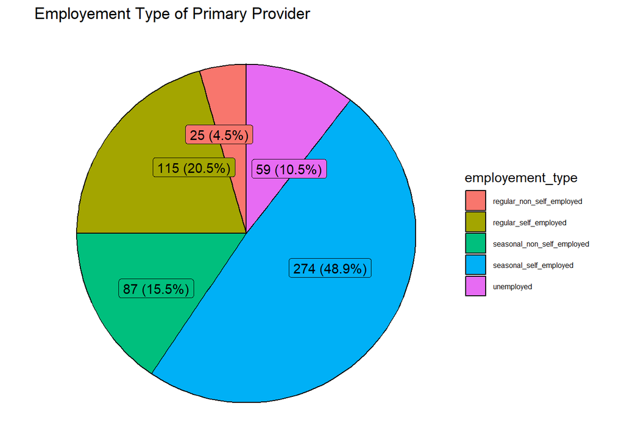

```r
# Type of employment for Primary Provider
plot_func(df=initial_pre, var_name="employement_type",
          var_type="non_cont", plot_title="Employement Type of Primary Provider",
          plot_type="pie")
```

### Occupation Change

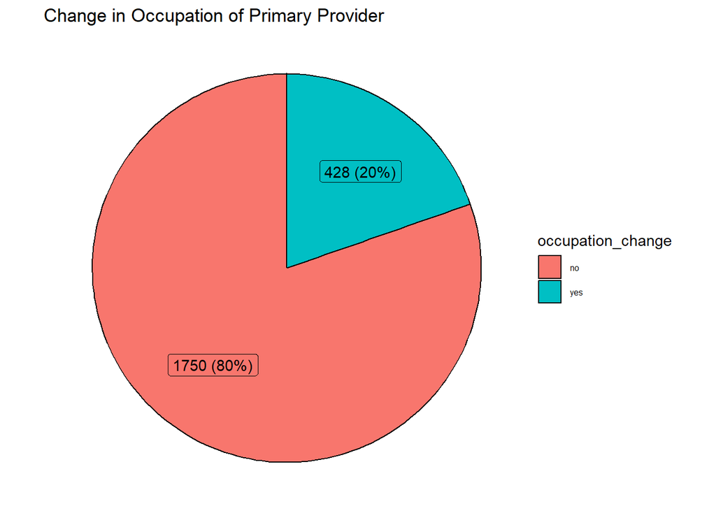

```r
# Has your (or your spouses) occupation changed since youve been connected to minigrid power?
plot_func(df=post_clean, var_name="occupation_change",
          var_type="non_cont", plot_title="Change in Occupation of Primary Provider",
          plot_type="pie")
```

### Household Income

```
## [1] "Removing outliers"
```

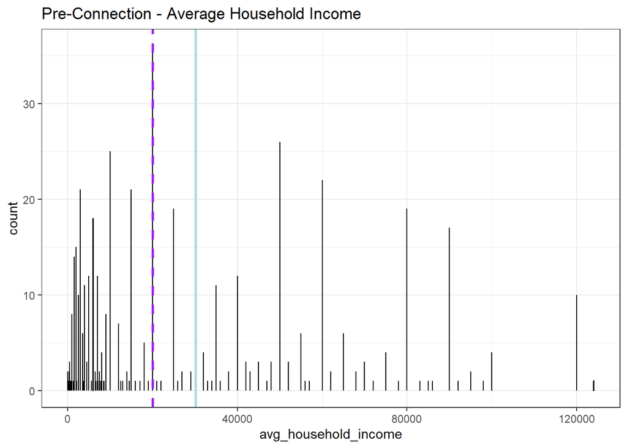

```r
# What is your average monthly household income:
# compare_pre_post(var_name="avg_household_income", var_type="cont",
#                  subplot_type="hist", char_remove = 0, exclude_outliers = TRUE,
#                  title="Average Household Income", shared_legend=FALSE)
plot_func(df=initial_pre, var_name="avg_household_income",
          var_type="cont", plot_title="Pre-Connection - Average Household Income",
          plot_type="hist", char_remove = 0, remove_outliers = TRUE)
```

```
## [1] "Removing outliers"
```

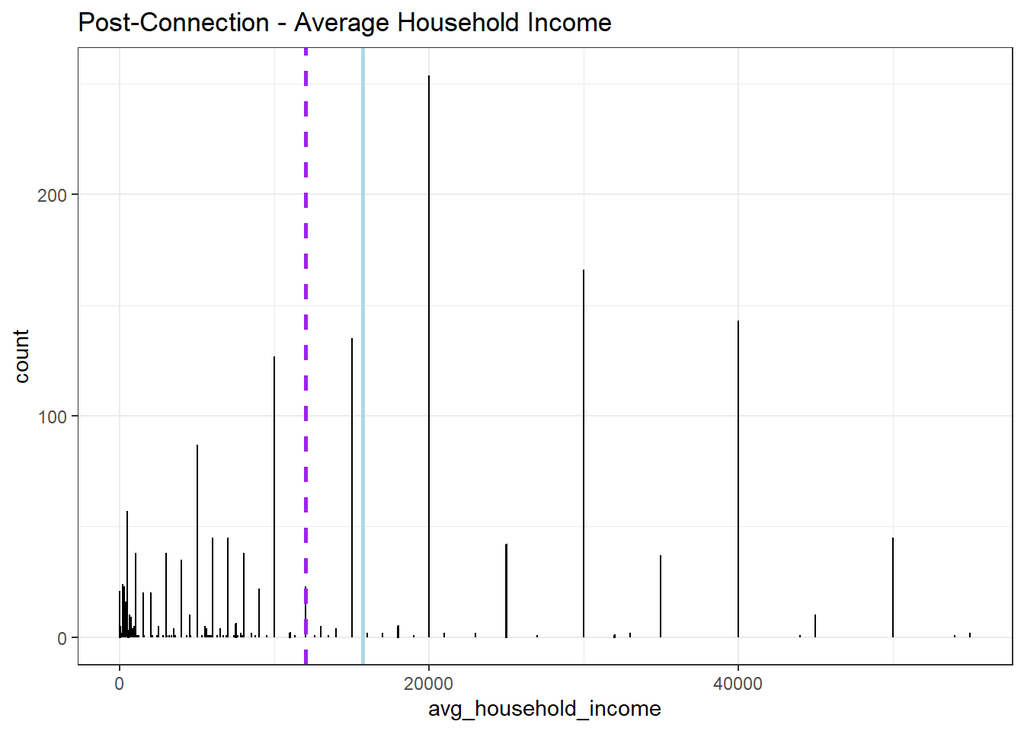

```r
plot_func(df=post_clean, var_name="avg_household_income",
          var_type="cont", plot_title="Post-Connection - Average Household Income",
          plot_type="hist", char_remove = 0, remove_outliers = TRUE)
```

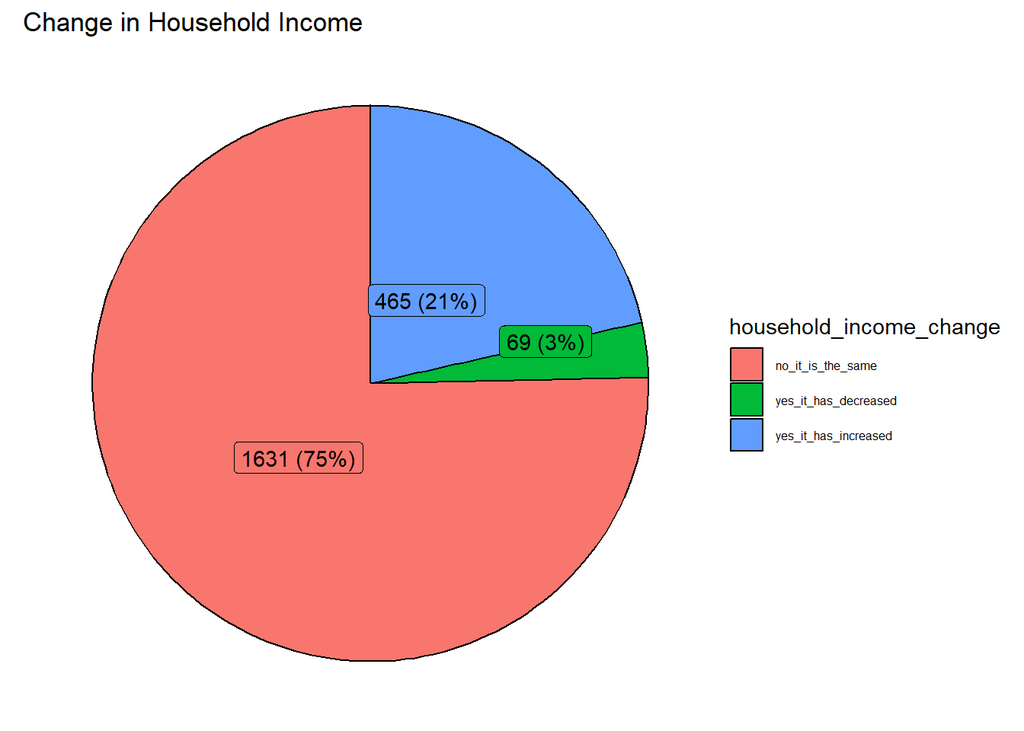

```r
# Has your household income changed since your connection to minigrid power?
plot_func(df=post_clean, var_name="household_income_change",
          var_type="non_cont", plot_title="Change in Household Income",
          plot_type="pie")
```

### TODO: Costs - Additional Cleaning

#### Phone Charging

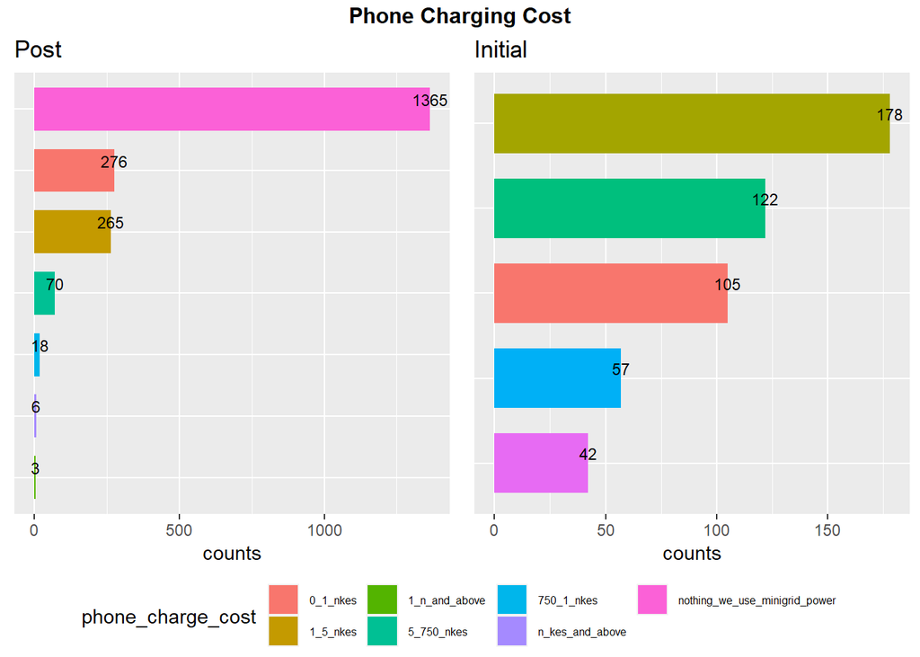

```r
# How much do you pay per month to charge your mobile phone?
compare_pre_post(var_name="phone_charge_cost", var_type="non_cont",
                 subplot_type="bar",
                 title="Phone Charging Cost", shared_legend=TRUE)
```

#### Appliances Charging

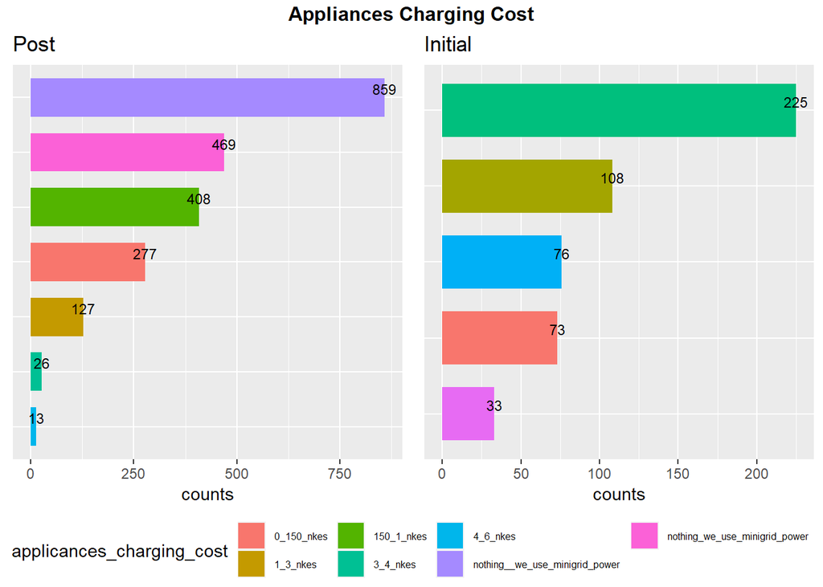

```r
# What is approximate monthly cost of energy used strictly for charging appliances?
compare_pre_post(var_name="applicances_charging_cost", var_type="non_cont",
                 subplot_type="bar",
                 title="Appliances Charging Cost", shared_legend=TRUE)
```

#### Cooking Energy

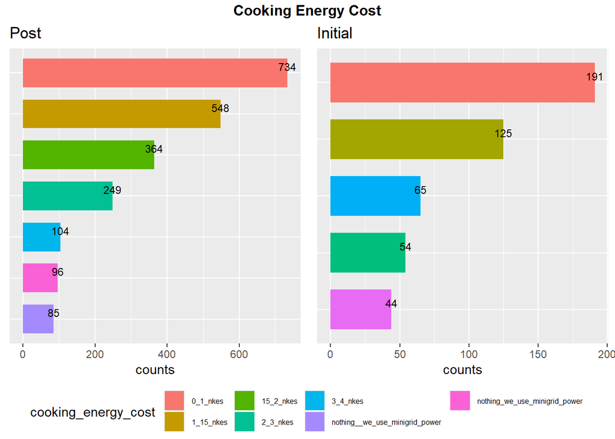

```r
# What is the approximate monthly cost of energy used strictly for cooking?
compare_pre_post(var_name="cooking_energy_cost", var_type="non_cont",
                 subplot_type="bar",
                 title="Cooking Energy Cost", shared_legend=TRUE)
```

#### Kerosene Lamps

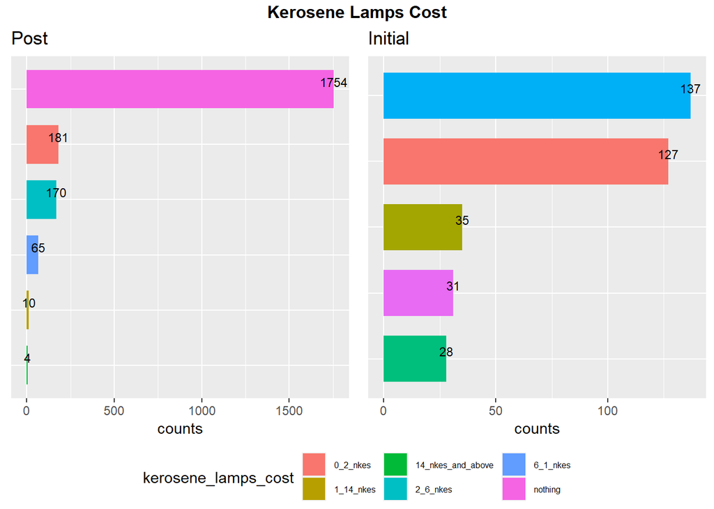

```r
# How much do you pay monthly for kerosene used only in kerosene lamps?
compare_pre_post(var_name="kerosene_lamps_cost", var_type="non_cont",
                 subplot_type="bar",
                 title="Kerosene Lamps Cost", shared_legend=TRUE)
```

### TODO: Local Business Creation

```r
# Are any household members business owners?
# Is this business recent (started after connection to minigrid power?)
# If this business is new, do you consider this new business a result of having access to minigrid power?
```

## B) Inferential

### Avg. Household Income*

**Data Source**: Paired Household Surveys (Pre & Post)

**Value (Encoding if applied)**: Any numeric value

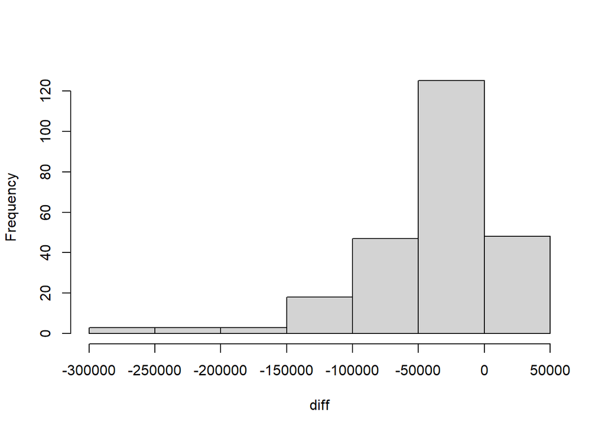

```
##
##  Paired t-test
##
## data:  var_pre and var_post
## t = 10.169, df = 246, p-value < 0.00000000000000022
## alternative hypothesis: true mean difference is not equal to 0
## 95 percent confidence interval:
##  27897.89 41301.44
## sample estimates:
## mean difference
##        34599.66
```

```r
## What is your average monthly household income?
nigeria_df <- paired_clean %>% filter(country_post == "nigeria")
paired_testing(nigeria_df, var_name="avg_household_income",
               test_type = "ttest", plot_diff=TRUE)
```

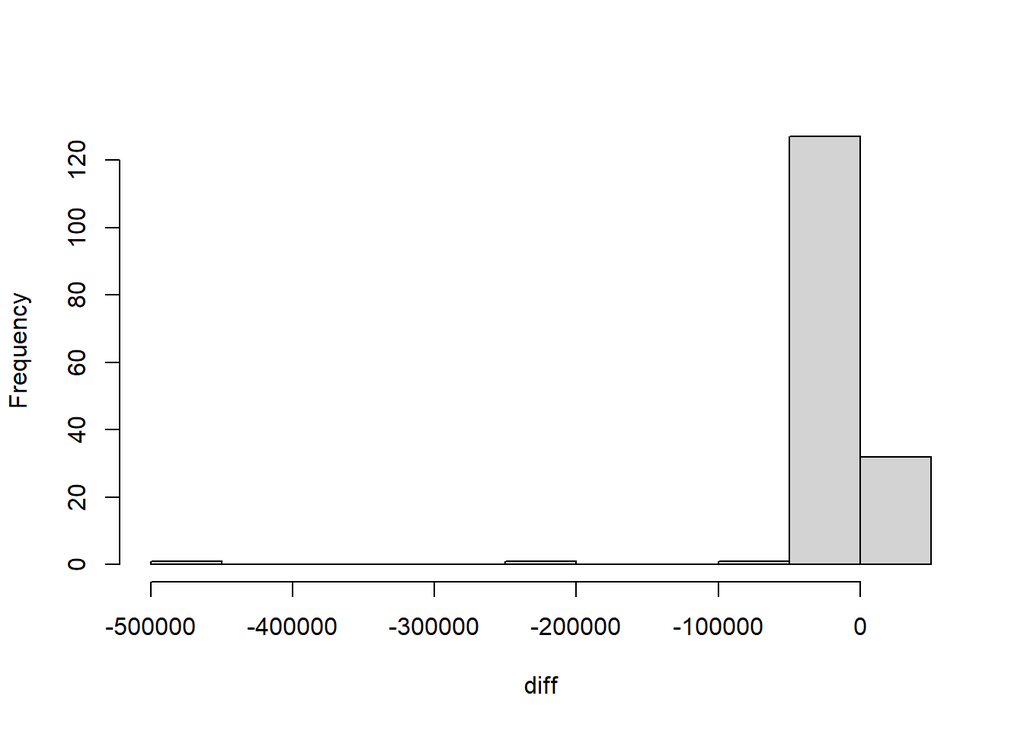

```
##
##  Paired t-test
##
## data:  var_pre and var_post
## t = 2.3684, df = 161, p-value = 0.01905
## alternative hypothesis: true mean difference is not equal to 0
## 95 percent confidence interval:
##   1360.192 15008.882
## sample estimates:
## mean difference
##        8184.537
```

```r
kenya_df <- paired_clean %>% filter(country_post == "kenya")
paired_testing(kenya_df, var_name="avg_household_income",
               test_type = "ttest", plot_diff=TRUE)
```

#### TODO: Needs further Investigation on negative differences

### Household - Income Change

**Data Source**: Household Post Survey

**Value (Encoding if applied)**: “Yes, it’s decreased” = -1; “No, it’s the same” = 0; “Yes, it’s increased” = 1

```r
## Has your household income changed since your connection to mini-grid power?
community_reg(df=post_enc,
              col_name="household_income_change", dep="1",
              title="Household Income Increase by Community",
              var_type="categorical", calc_diff = FALSE)
```

```
## [1] "pv_size_kwh"
##                  Estimate   Std. Error    t value    Pr(>|t|)
## Intercept    0.2796759373 0.0572067596  4.8888617 0.000118157
## pv_size_kwh -0.0003207952 0.0004595888 -0.6980047 0.494093432
##                              2.5 %       97.5 %
## (Intercept)            0.159488995 0.3998628793
## community_data[, ind] -0.001286356 0.0006447652
## [1] "customer_count"
##                      Estimate    Std. Error   t value     Pr(>|t|)
## Intercept       0.29660583953 0.05993384712  4.948887 0.0001037144
## customer_count -0.00009757944 0.00009105225 -1.071686 0.2980203830
##                               2.5 %        97.5 %
## (Intercept)            0.1706894992 0.42252217989
## community_data[, ind] -0.0002888731 0.00009371424
## [1] "capex_usd"
##                   Estimate      Std. Error    t value    Pr(>|t|)
## Intercept  0.3062749951369 0.0919410167796  3.3312117 0.003716104
## capex_usd -0.0000001687728 0.0000002953022 -0.5715257 0.574711305
##                                  2.5 %          97.5 %
## (Intercept)            0.1131140865825 0.4994359036912
## community_data[, ind] -0.0000007891798 0.0000004516342
## [1] "consumption"
##                     Estimate    Std. Error   t value      Pr(>|t|)
## Intercept    0.3082574635153 0.06039114268  5.104349 0.00007411336
## consumption -0.0000009408182 0.00000069767 -1.348515 0.19421699827
##                                 2.5 %          97.5 %
## (Intercept)            0.181380380823 0.4351345462076
## community_data[, ind] -0.000002406569 0.0000005249322
```

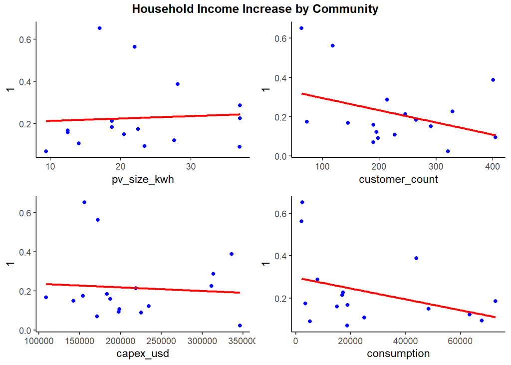

### C&I - Earnings Change

**Value (Encoding if applied)**: “Yes, it’s decreased” = -1; “No, it’s the same” = 0; “Yes, it’s increased” = 1

```r
# For businesses or shop owners only: Since connection to Renewvia mini-grid, have you seen any change in your weekly or monthly earnings?
community_reg(df=ci_enc,
              col_name="earnings_change", dep="1",
              title="C&I Earnings Increase by Community",
              var_type="categorical", calc_diff = FALSE)
```

```
## [1] "pv_size_kwh"
##                 Estimate   Std. Error  t value      Pr(>|t|)
## Intercept   0.6281744487 0.1116055696 5.628522 0.00006223704
## pv_size_kwh 0.0005347319 0.0008045037 0.664673 0.51705914202
##                              2.5 %      97.5 %
## (Intercept)            0.388804309 0.867544589
## community_data[, ind] -0.001190757 0.002260221
## [1] "customer_count"
##                     Estimate   Std. Error   t value   Pr(>|t|)
## Intercept      0.63585103193 0.1190643977 5.3403960 0.00010425
## customer_count 0.00006420572 0.0001643487 0.3906677 0.70192306
##                               2.5 %       97.5 %
## (Intercept)            0.3804832966 0.8912187672
## community_data[, ind] -0.0002882871 0.0004166986
## [1] "capex_usd"
##                  Estimate      Std. Error   t value    Pr(>|t|)
## Intercept 0.5525334726977 0.1778396633562 3.1069192 0.007725478
## capex_usd 0.0000003853656 0.0000005264488 0.7320098 0.476238877
##                                  2.5 %         97.5 %
## (Intercept)            0.1711053301475 0.933961615248
## community_data[, ind] -0.0000007437547 0.000001514486
## [1] "consumption"
##                    Estimate     Std. Error   t value     Pr(>|t|)
## Intercept   0.6436815698622 0.122962586431 5.2347758 0.0001263041
## consumption 0.0000003091192 0.000001301067 0.2375889 0.8156416957
##                                 2.5 %         97.5 %
## (Intercept)            0.379953051374 0.907410088350
## community_data[, ind] -0.000002481393 0.000003099631
```

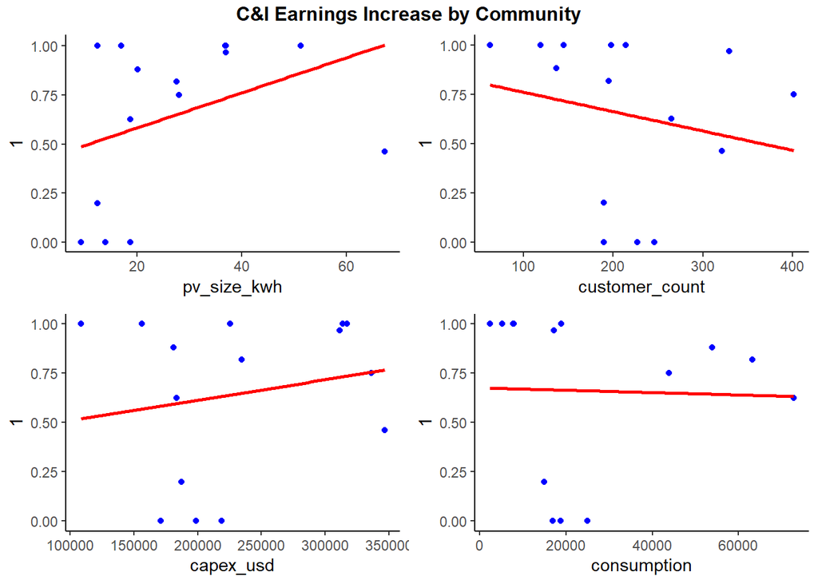

```r
df_pos <- ci_enc %>% filter(earnings_change != -1)
consumption_reg(df = df_pos, reg_type ="logistic",
                dep= "earnings_change",
                title="Energy Consumption vs. C&I Earnings Increase")
```

```
## Wald test:
## ----------
##
## Chi-squared test:
## X2 = 116.1, df = 1, P(> X2) = 0.0
##
## Call:
## glm(formula = df[, dep] ~ df$Energy.Consumption, family = binomial)
##
## Coefficients:
##                         Estimate Std. Error z value            Pr(>|z|)
## (Intercept)            1.8428303  0.1710133   10.78 <0.0000000000000002 ***
## df$Energy.Consumption -0.0002589  0.0001301   -1.99              0.0466 *
## ---
## Signif. codes:  0 '***' 0.001 '**' 0.01 '*' 0.05 '.' 0.1 ' ' 1
##
## (Dispersion parameter for binomial family taken to be 1)
##
##     Null deviance: 259.37  on 306  degrees of freedom
## Residual deviance: 254.80  on 305  degrees of freedom
## AIC: 258.8
##
## Number of Fisher Scoring iterations: 4
```

```
##                               2.5 %         97.5 %
## (Intercept)            1.5198684347  2.19198780350
## df$Energy.Consumption -0.0005602814 -0.00002225437
```

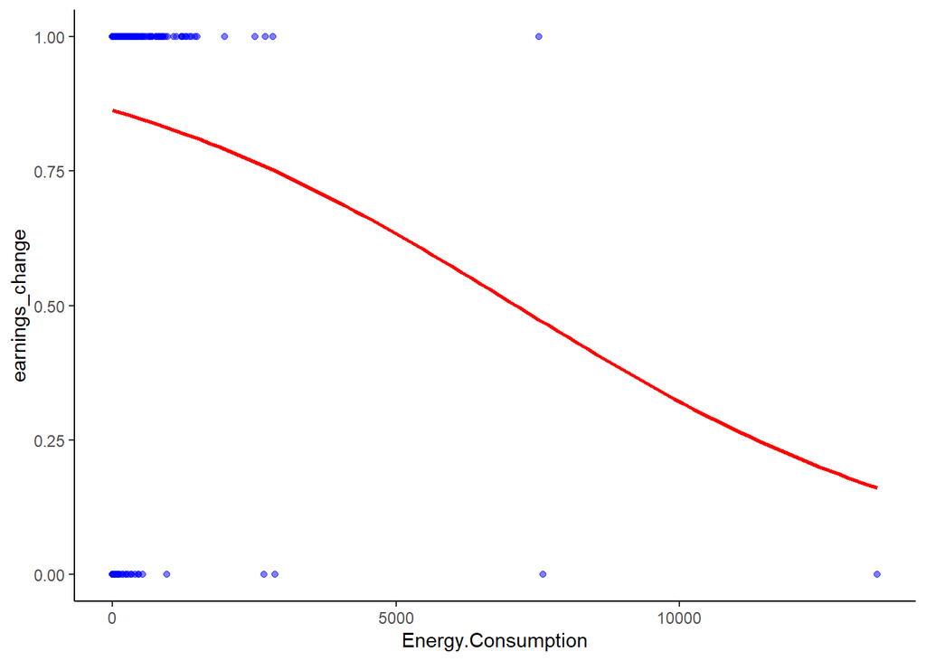

### Business Ownership

**Data Source**: Paired Household Surveys (Pre & Post)

**Value (Encoding if applied)**: “None” = 0; “Not None” = 1

```r
# Are any household members business owners?
## McNemar's Test
paired_testing(paired_enc, var_name="business_owners_binary",
               test_type = "mcnemar", plot_diff=FALSE)
```

```
##        var_post
## var_pre   0   1
##       0  68  55
##       1   9 337
```

```
##
##  McNemar's Chi-squared test with continuity correction
##
## data:  cross_tab
## McNemar's chi-squared = 31.641, df = 1, p-value = 0.00000001855
```

```r
community_reg(df=paired_enc,
              col_name="business_owners_binary", dep="1",
              title="Household Business Onwership by Community",
              var_type="categorical", calc_diff =TRUE)
```

```
## [1] "pv_size_kwh"
##                 Estimate   Std. Error    t value    Pr(>|t|)
## Intercept    0.321912978 0.0969324306  3.3210039 0.005520108
## pv_size_kwh -0.000657438 0.0006787279 -0.9686327 0.350405182
##                             2.5 %       97.5 %
## (Intercept)            0.11250319 0.5313227630
## community_data[, ind] -0.00212374 0.0008088644
## [1] "customer_count"
##                   Estimate   Std. Error    t value    Pr(>|t|)
## Intercept       0.33677599 0.1045812553  3.2202328 0.006701419
## customer_count -0.00013368 0.0001386372 -0.9642432 0.352519072
##                               2.5 %       97.5 %
## (Intercept)            0.1108419276 0.5627100598
## community_data[, ind] -0.0004331875 0.0001658275
## [1] "capex_usd"
##                   Estimate      Std. Error   t value    Pr(>|t|)
## Intercept  0.4759347158282 0.1406655602270  3.383449 0.004895578
## capex_usd -0.0000007057293 0.0000004152317 -1.699604 0.112991883
##                                 2.5 %          97.5 %
## (Intercept)            0.172045248470 0.7798241831864
## community_data[, ind] -0.000001602783 0.0000001913241
## [1] "consumption"
##                    Estimate     Std. Error   t value    Pr(>|t|)
## Intercept    0.346835636148 0.107504143808  3.226254 0.006624198
## consumption -0.000001134682 0.000001096228 -1.035078 0.319503911
##                                 2.5 %         97.5 %
## (Intercept)            0.114587053425 0.579084218871
## community_data[, ind] -0.000003502939 0.000001233575
```

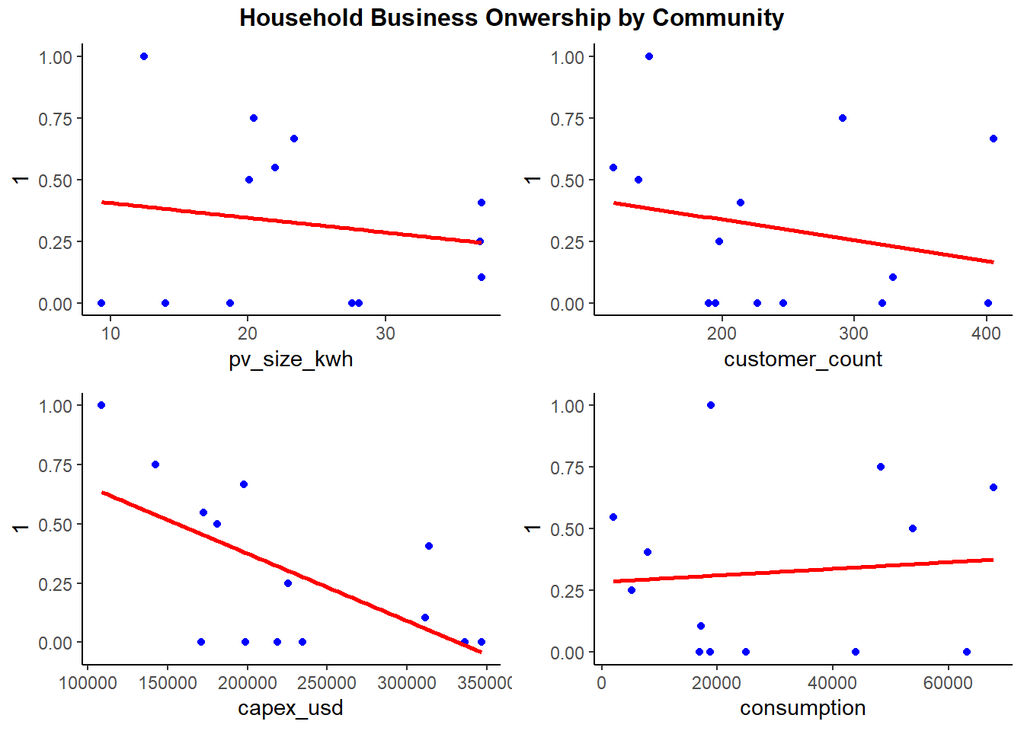

### TODO: Regression with energy consumption in both directions (1, -1)